# Grupo Bimbo - Prevendo Demanda de Estoque com Base em Vendas

Victor Saraiva Rocha

22/04/2021

#### **Projeto de conclusão de curso 2 -> Data Science Academy - Big Data Analytics com R e Microsoft Azure Machine Learning.**

## **1.Descrição do projeto.**

À esse projeto será utilizado o dataset disponibilizado na competição [Grupo Bimbo Inventory Demand](https://www.kaggle.com/c/grupo-bimbo-inventory-demand/data).

O Grupo Bimbo (https://www.grupobimbo.com), se esforça para atender a demanda diária dos consumidores por produtos frescos de panificação nas prateleiras de mais de 1 milhão de lojas ao longo das suas 45.000 lojas em todo o México.

Atualmente, os cálculos diários de estoque são realizados por funcionários de vendas de entregas diretas, que devem, sozinhos, prever a necessidade de estoque dos produtos e demanda com base em suas experiências pessoais em cada loja. Como alguns pães têm uma vida útil de uma semana, a margem aceitável para o erro é pequena.

Neste projeto de aprendizado de máquina, você deve desenvolver um modelo para prever com precisão a demanda de estoque com base nos dados históricos de vendas. Isso fará com que os consumidores dos mais de 100 produtos de panificação não fiquem olhando para as prateleiras vazias, além de reduzir o valor gasto com reembolsos para os proprietários de lojas com produtos excedentes impróprios para venda.

### **1.1 Objetivo.**

o Objetivo desse projeto será criarmos um algoritmo de machine learning que faça predições para **maximizar** as vendas e **miniziar** o retorno dos produtos de panificação.

Ao projeto será considerado um bom modelo caso a taxa de **acurácia** chegue à **90%**.

## **2. Pré-processamento.**

Vamos carregar as bibliotecas necessárias para iniciarmos nosso projeto.

```r
# Carregando os pacotes necessário ao projeto
library(data.table)
library(dplyr)
library(ggplot2)
library(stringr)
library(moments)
library(caret)
library(imager)
```

Com os pacotes carregados, vamos remover a notação científica para melhor visualização dos gráficos e aumentar o limite de memória de processamento.

```r
# Removendo a notação científica
options(scipen = 1000000)

# Aumentandoo limite de memória de processamento.
memory.limit(999999999999)
```

De acordo com a documentação original, temos informações importantes reespeito dos dados:

1. Existem Clientes com ID’s duplicados, o que significa que um Cliente_ID pode ter vários nomes que são muito semelhantes. Isso se deve ao fato do nome do cliente não ser padronizado nos dados brutos, portanto, precisaremos limpar e usar essas informações.
2. A demanda ajustada (Demanda_uni_equil) é sempre >= 0, pois a demanda deve ser 0 ou um valor positivo. A razão pela qual Venta_uni_hoy - Dev_uni_proxima às vezes tem valores negativos é que os registros de retorno às vezes perduram por algumas semanas.

Nessa etapa, podemos econtrar inconsistências nos dados brutos que precisarão de algum tratamento para conseguirmos tirar informações dos dados. Começaremos pelos dados de clientes.

```r
# Carregando os dados com os clientes.
clientes <- fread('cliente_tabla.csv')

# Verificando a quantidade de linhas.
nrow(clientes)
```

```
## [1] 935362
```

```r
# Vendo as 15 primeiras linhas dos dados.
head(clientes, 15)
```

```
##     Cliente_ID                           NombreCliente
##  1:          0                              SIN NOMBRE
##  2:          1                        OXXO XINANTECATL
##  3:          2                              SIN NOMBRE
##  4:          3                               EL MORENO
##  5:          4 SDN SER  DE ALIM  CUERPO SA CIA  DE INT
##  6:          4    SDN SER DE ALIM CUERPO SA CIA DE INT
##  7:          5                              LA VAQUITA
##  8:          6                                  LUPITA
##  9:          7                            I M EL GUERO
## 10:          8                    MINI SUPER LOS LUPES
## 11:          9               SUPER KOMPRAS MICRO COLON
## 12:         10                 LONJA MERCANTIL DE TODO
## 13:         11               FARMACIA NICOLAS SAN JUAN
## 14:         12                        PAPELERIA CATALA
## 15:         13                                   ELENA
```

Temos um total de **935.362** registros de clientes. Vamos verificar quantos ID’s diferentes temos nos dados de clientes. Como o correto é termos uma ID para cada cliente, podemos utilizar essa variável para sabermos se temos duplicidade nos dados de clientes.

```r
# Verificando Quantidade de ID's únicos
length(unique(clientes$Cliente_ID))
```

```
## [1] 930500
```

Podemos ver que a quantidade de ID’s únicos não é igual ao número total de registros, dessa forma sabemos que existem ID’s que estão se repetindo dentro dos dados de clientes. Vejamos quantos são os registros duplicados.

```r
# Verificando registros duplicados.
nrow(clientes) - length(unique(clientes$Cliente_ID))
```

```
## [1] 4862
```

Temos um total de **4.862** registros com ID’s repetidas, teremos que averiguar o motivo dessas repetições. Verificaremos se há algum valor indisponível nos clientes.

```r
# Validando se existe algum valor NA.
anyNA(clientes)
```

```
## [1] FALSE
```

Como vimos não temos nenhum valor NA nos dados de clientes.

Conforme vimos, nas 15 primeris linhas dos dados existem nomes de clientes que possuem como nome **‘SIN NOMBRE’**. Vamos criar um subset dos clientes para avaliarmos quantos clientes estão sem nome.

```r
# Criando um subset dos dados de clientes.
clientes_sem_nome <- clientes[str_which(clientes$NombreCliente, 'SIN NOMBRE')]
```

```r
# salvando as informações num arquivo csv.
fwrite(clientes_sem_nome, 'clientes_sem_nome.csv')
```

```r
# Verificando a quantidade de registros.
nrow(clientes_sem_nome)
```

```
## [1] 379
```

Podemos ver que temos um total de **379** clientes sem nome. Vamos analisar as 15 primeiras linhas dos dados para vermos se realmente carregamos apenas clientes sem nome.

```r
# verificando as 15 primeiras linhas dos dados
head(clientes_sem_nome, 15)
```

```
##     Cliente_ID         NombreCliente
##  1:          0            SIN NOMBRE
##  2:          2            SIN NOMBRE
##  3:         34            SIN NOMBRE
##  4:      10119            SIN NOMBRE
##  5:      16947            SIN NOMBRE
##  6:      31216            SIN NOMBRE
##  7:      31713            SIN NOMBRE
##  8:      48679   DULCERIA SIN NOMBRE
##  9:      50444 MISCELANEA SIN NOMBRE
## 10:      50580      SIN NOMBRE MARIA
## 11:      51477            SIN NOMBRE
## 12:      53884            SIN NOMBRE
## 13:      57274            SIN NOMBRE
## 14:      57322            SIN NOMBRE
## 15:      57694            SIN NOMBRE
```

Podemos ver que existem clientes com nomes genéricos somados à palavra **“SIN NOMBRE”**. Vamos retirar do nosso subset apenas os registros que apresentam nomes genéricos.

```r
# Criando uma variável com os registros sem nome.
genericos <- clientes_sem_nome[!str_which(clientes_sem_nome$NombreCliente, '^SIN NOMBRE$')]
```

```r
# salvando as informações num arquivo csv.
fwrite(genericos, 'nomes_genericos.csv')
```

```r
# verificando os registros.
genericos
```

```
##     Cliente_ID                  NombreCliente
##  1:      48679            DULCERIA SIN NOMBRE
##  2:      50444          MISCELANEA SIN NOMBRE
##  3:      50580               SIN NOMBRE MARIA
##  4:      58992        SIN NOMBRESILVIA SUAREZ
##  5:      58996 SIN NOMBREPRECILIANO CASTREJON
##  6:      59353    PUESTO DE DULCES SIN NOMBRE
##  7:     138033                  SIN NOMBREANA
##  8:     207795                ABTS SIN NOMBRE
##  9:     411897           ABARROTES SIN NOMBRE
## 10:     458509           ABARROTES SIN NOMBRE
## 11:     460583           ABARROTES SIN NOMBRE
## 12:     460669           ABARROTES SIN NOMBRE
## 13:     533047           ABARROTES SIN NOMBRE
## 14:     678414                  AB SIN NOMBRE
## 15:    1691317          MISCELANEA SIN NOMBRE
## 16:    1773118           ABARROTES SIN NOMBRE
## 17:    1940983          MISCELANEA SIN NOMBRE
## 18:    2138648           ABARROTES SIN NOMBRE
## 19:    2142343          RECAUDERIA SIN NOMBRE
## 20:    2259560              TORTAS SIN NOMBRE
## 21:    2303521          MISCELANEA SIN NOMBRE
## 22:    2461131          MISCELANEA SIN NOMBRE
## 23:    2485882          MISCELANEA SIN NOMBRE
##     Cliente_ID                  NombreCliente
```

Podemos ver que temos um total de 23 registros com nomes genéricos. Vejamos se temos ID’s duplicados dentro dos clientes com nomes genéricos.

```r
# Validando se há algum ID duplicado.
anyDuplicated(genericos$Cliente_ID)
```

```
## [1] 0
```

Pudemos ver que temos 23 ID’s com nomes genéricos e nenhuma se repete. Vamos validar a necessidade de limpeza desses registros ou se podemos remover os clientes com esses ID’s.

Para avaliação, vamos carregar a base de dados para sabermos quantas linhas de cada ID temos. Como o conjunto de dados possui quase 4GB, tiraremos uma amostra dos dados de 25% dos dados.

```r
# Carregando o conjunto de dados.
dados <- fread('train.csv', encoding = 'UTF-8')

# Criando uma amostra dos dados.
dados <- dados[sample(1:nrow(dados), round(nrow(dados)/4))]

# Salvando os dados num arquivo csv.
fwrite(dados, 'amostra_train.csv')
```

```r
# verificando a quantidade total de linhas do conjunto de dados.
nrow(dados)
```

```
## [1] 18545116
```

Podemos ver que temos um total de **18.545.116** linhas ou registros em nosso conjunto de dados. Vejamos se podemos ou não remover os clientes com nomes genéricos. Caso possuam uma quantidade representativa de observações não poderemos fazer sua remoção, teremos que tratar seus nomes genéricos.

```r
# Verificando a quantidade total dos registros com nomes genéricos.
dados[Cliente_ID %in% genericos$Cliente_ID, .(Registros_totais = .N,
                                              Percentual = round(.N / nrow(dados) * 100, digits = 4))]
```

```
##    Registros_totais Percentual
## 1:              725     0.0039
```

Conforme podemos ver os clientes com nomes genéricos possuem apenas **725** registros ou **0,0039%** do total. Com isso optaremos por remover esses ID’s de nossos conjuntos de dados. Porém, antes de realizarmos a limpeza desses clientes, analisaremos os clientes que possuem como nome apenas “SIN NOMBRE”.

```r
# Criando uma variável com os clientes sem nomes.
apenas_sem_nome <- clientes_sem_nome[str_which(clientes_sem_nome$NombreCliente, '^SIN NOMBRE$')]
```

```r
# salvando as informações num arquivo csv.
fwrite(apenas_sem_nome, 'apenas_sem_nome.csv')
```

```r
# Verificando os registros.
apenas_sem_nome
```

```
##      Cliente_ID NombreCliente
##   1:          0    SIN NOMBRE
##   2:          2    SIN NOMBRE
##   3:         34    SIN NOMBRE
##   4:      10119    SIN NOMBRE
##   5:      16947    SIN NOMBRE
##  ---
## 352:    4774171    SIN NOMBRE
## 353:    4774332    SIN NOMBRE
## 354:    4776231    SIN NOMBRE
## 355:    4776554    SIN NOMBRE
## 356:    7933034    SIN NOMBRE
```

Podemos ver que temos **356** clientes com nomes **SIN NOMBRE** . Vamos ver se temos algun ID que se repete.

```r
# Validando se há algum ID duplicado.
anyDuplicated(apenas_sem_nome$Cliente_ID)
```

```
## [1] 0
```

Não temos ID repetido. Agora vamos verificar se podemos ou não remover os clientes com registros de nomes “SIN NOMRE” de nossos dados. Caso possuam uma quantidade representativa de registros, não poderemos fazer sua remoção, teremos que tratar seus nomes.

```r
# Verificando a quantidade dos registros com nomes "SIN NOMBRE".
dados[Cliente_ID %in% apenas_sem_nome$Cliente_ID, .(Registros_totais = .N,
                                                    Percentual = round(.N / nrow(dados) * 100, digits = 4))]
```

```
##    Registros_totais Percentual
## 1:             1202     0.0065
```

Como podemos ver temos um total de apenas **1.202** registros com nomes “SIN NOMBRE” e equivalem à apenas 0,0065% do total dos dados. Com isso, também optaremos em remover os ID’s de clientes com nomes “SIN NOMBRE”. Criarei um operador para negarmos o operador %in% e removermos esses ID’s de nosso conjunto de dados.

```r
# Criando um operador de negação do operador %in%.
'%notin%' <- Negate('%in%')

# Removendo os ID's com nomes genéricos e "SIN NOMBRE" de nosso registro de clientes.
clientes <- clientes[Cliente_ID %notin% genericos$Cliente_ID & Cliente_ID %notin% apenas_sem_nome$Cliente_ID]
```

Contudo ainda não finalizamos nossa limpeza nos dados de clientes. Conforme vimos anteriormente, temos ID’s duplicados nos clientes. Como fizemosa remoção de algumas ID’s vamos ver quantas observações duplicadas ainda temos.

```r
# Verificando a quantidade de registros duplicados nos ID's de clientes.
length(which(duplicated(clientes$Cliente_ID)))
```

```
## [1] 4861
```

Ainda permanecemos permanecemos com **4.861** registros duplicados em nos dados de clientes. Vamos utilizar esses registros para avaliarmos as variações em seus nomes.

```r
# Criando um subset dos dados de clientes.
id_duplicado <- clientes[duplicated(clientes$Cliente_ID), Cliente_ID]

# Visualizando as variações dos nomes.
clientes[Cliente_ID %in% id_duplicado, .(Quantidade = .N), by = Cliente_ID]
```

```
##       Cliente_ID Quantidade
##    1:          4          2
##    2:        262          2
##    3:        465          2
##    4:       1589          2
##    5:       2033          2
##   ---
## 4857:    9517439          2
## 4858:    9532710          2
## 4859:    9533930          2
## 4860:    9612023          2
## 4861:    9694173          2
```

Como vimos tanto os 5 primeiros quanto os 5 últimos ID’s se repetem apenas 2 vezes. Vamos confirmar se essa informação também se dá aos demais clientes. Verificando se existem clientes que se repetem mais que duas vezes.

```r
# Verificando quais clientes repetem mais de 2 vezes.
clientes[Cliente_ID %in% id_duplicado, .(Quantidade = .N), by = Cliente_ID][Quantidade > 2]
```

```
## Empty data.table (0 rows and 2 cols): Cliente_ID,Quantidade
```

Pudemos ver que não temos clientes que se repetem mais que duas vezes. Dessa forma, faremos apenas uma remoção dos ID’s duplicados.

```r
# Removendo os registros duplicados dos dados de clientes.
clientes <- clientes[!duplicated(clientes$Cliente_ID)]

# Validando a remoção dos registros duplicados.
length(which(duplicated(clientes$Cliente_ID)))
```

```
## [1] 0
```

Como vimos não temos mais nenhum ID que se repete. Vamos visualizar como ficou nossos dados de clientes.

```r
# Visualizando os clientes.
clientes
```

```
##         Cliente_ID                           NombreCliente
##      1:          1                        OXXO XINANTECATL
##      2:          3                               EL MORENO
##      3:          4 SDN SER  DE ALIM  CUERPO SA CIA  DE INT
##      4:          5                              LA VAQUITA
##      5:          6                                  LUPITA
##     ---
## 930117:   11011586                              OXXO PETEN
## 930118:   11693264                    SUPER ABARROTES MARY
## 930119:   19988629                         NO IDENTIFICADO
## 930120:   99999999                         NO IDENTIFICADO
## 930121: 2015152015                         NO IDENTIFICADO
```

Como podemos ver, existem algumas ID’s que estão com o nome **“NO IDENTIFICADO”**. Vamos realizar as mesmas análises que fizemos aos clientes **“SIN NOMBRE”**.

```r
# Criando uma variável com os ID's de nomes "NO IDENTIFICADO".
no_identificado <- clientes[str_which(clientes$NombreCliente, regex('identificado', ignore_case = T))]

# Verificando a quantidade de registros.
nrow(no_identificado)
```

```
## [1] 281670
```

Como podemos ver temos um total de **281.670** ID’s de clientes com nome “NO IDENTIFICADO”. Vejamos se há algum ID duplicado.

```r
# Vamos ver se temos ID's duplicados.
anyDuplicated(no_identificado$Cliente_ID)
```

```
## [1] 0
```

Como vimos não temos nenhum ID que se repete. Agora, precisamos saber quanto esses ID’s equivalem do total.

```r
# Verificando a quantidade total dos registros com nome "NO IDENTIFICADO".
dados[Cliente_ID %in% no_identificado$Cliente_ID, .(Num_registros = .N,
                                                    Percentual = round(.N / nrow(dados) * 100, digits = 4))]
```

```
##    Num_registros Percentual
## 1:       3313968    17.8698
```

Podemos ver que temos **3.313.968** registros de ID’s com nome **NO IDENTIFICADO** que equivalem à **17,87%** do total aproximadamente. Devido ao alto percentual desses registros não poderemos removê-los de nossos dados, nesse caso faremos uma alteração nos nomes desses ID’s. Faremos um sequenciamento de cada nome para diferenciarmos cada ID.

```r
# Sequenciando o nome **NO IDENTIFICADO** para diferenciação das ID's.
no_identificado[, ('NombreCliente') := lapply(.SD, function(cols){
  i <- seq(nrow(no_identificado))
  paste('NO IDENTIFICADO_', i, sep = '')}),
  .SDcols = 'NombreCliente']
```

Agora vamos validar se ainda existe algum nome duplicado.

```r
# Validando o sequênciamento dos nomes.
length(which(duplicated(no_identificado$NombreCliente)))
```

```
## [1] 0
```

Pudemos ver que não temos mais nenhum cliente com nome repetido. Agora precisamos alterar os nomes desses ID’s nos dados originais de clientes.

```r
# Alterando os nomes dos clientes nos dados originais.
clientes[Cliente_ID %in% no_identificado$Cliente_ID, NombreCliente := no_identificado$NombreCliente]

# Validando a substituição dos nomes.
clientes[str_which(clientes$NombreCliente, regex('identificado', ignore_case = T))]
```

```
##         Cliente_ID          NombreCliente
##      1:    2465096      NO IDENTIFICADO_1
##      2:    2465098      NO IDENTIFICADO_2
##      3:    2465102      NO IDENTIFICADO_3
##      4:    2465104      NO IDENTIFICADO_4
##      5:    2465105      NO IDENTIFICADO_5
##     ---
## 281666:    4776758 NO IDENTIFICADO_281666
## 281667:    9999999 NO IDENTIFICADO_281667
## 281668:   19988629 NO IDENTIFICADO_281668
## 281669:   99999999 NO IDENTIFICADO_281669
## 281670: 2015152015 NO IDENTIFICADO_281670
```

Como pudemos ver todos os clientes com o nome **NO IDENTIFICADO** receberam um número para os diferenciarmos. Contudo, ainda não finalizamos a limpeza em nossos dados de clientes. Nós averiguarmos se possuíamos ID’s duplicados, porém, ainda não sabemos se temos nomes duplicados.

```r
# Validando se temos diferentes ID's com mesmo nome.
length(which(duplicated(clientes$NombreCliente)))
```

```
## [1] 341456
```

Como pudemos ver temo **341.456** registros de ID’s diferentes com mesmo nome. Vamos criar um subset dos dados de clientes para analisarmos.

```r
# Criando um subset das ID's diferentes com mesmo nome.
nome_duplicado <- clientes[duplicated(clientes$NombreCliente),]

# Visualizando os 5 primerios nomes que mais se repetem.
nome_duplicado[, .(Nº_Repeticoes = .N), by = NombreCliente][order(-Nº_Repeticoes)][1:5]
```

```
##     NombreCliente Nº_Repeticoes
## 1:         LUPITA          4862
## 2:           MARY          3015
## 3:    LA PASADITA          2425
## 4:   LA VENTANITA          2266
## 5: LA GUADALUPANA          1298
```

Podemos ver que os nomes **LUPITA** e **MARY**são os nomes que mais se repetem. Vejamos quantos esses ID’s representam de nossos dados.

```r
# Verificando quantidade de registros com ID's diferentes, porém com nomes iguais.
dados[Cliente_ID %in% nome_duplicado$Cliente_ID, .(Num_registros = .N,
                                                   Percentual = round(.N / nrow(dados) * 100, digits = 4))]
```

```
##    Num_registros Percentual
## 1:       8035757    43.3309
```

Temos um total de **8.035.757** registros com ID’s diferentes, mas nomes iguais. Um total de **43,33%** do total aproximadamente. Não poderemos realizar a remoção desses registros, precisaremos fazer um tratamento em seus nomes. Utilizarei a mesma técnica de sequênciamento utilizada nos ID’s com o nome **NO IDENTIFICADO**.

```r
# Sequênciando os nomes dos clientes repetidos para diferenciá-los.
nome_duplicado$NombreCliente <- sapply(nome_duplicado[, 'NombreCliente'], function(linha){
  i <- seq(nrow(nome_duplicado))
  paste(linha, "_", i, sep = '')

})

# Validando o sequênciamento.
nome_duplicado
```

```
##         Cliente_ID               NombreCliente
##      1:       2073                 MONSERRAT_1
##      2:       2100                      PATY_2
##      3:       2103                      MARY_3
##      4:       2116                    LUPITA_4
##      5:       2150               LA PASADITA_5
##     ---
## 341452:   10351790        OXXO ALAMO II_341452
## 341453:   10351796           OXXO ALAMO_341453
## 341454:   10351814     OXXO DE LA LLAVE_341454
## 341455:   11011586           OXXO PETEN_341455
## 341456:   11693264 SUPER ABARROTES MARY_341456
```

Podemos ver que todos os nomes possuem uma numeração atrelada, isso faz com que possamos diferenciar cada ID de cliente. Vamos apenas confirmar se realmente não temos mais nomes duplicados em nosso subset.

```r
# Verificando quantidade de nomes duplicados.
length(which(duplicated(nome_duplicado$NombreCliente)))
```

```
## [1] 0
```

Realmente não temos mais nenhum nome duplicado em nossos dados. Vamos atualizar nossos dados de clientes originais.

```r
# Atualizando os dados de clientes.
clientes$NombreCliente[clientes$Cliente_ID %in% nome_duplicado$Cliente_ID] <- nome_duplicado$NombreCliente

# Validando a remoção dos nomes duplicados nos dados originais de clientes.
length(which(duplicated(clientes$NombreCliente)))
```

```
## [1] 0
```

Pudemos confirmar que realmente agora temos um nome para cada ID de cliente. Para garantirmos que os dados estão padronizados, vamos averiguar se existe algum nome de cliente que está com letra minúscula.

```r
# Verificando a quantidade de registros com letras minúsculas.
length(which(grepl('[:lower:]', clientes$NombreCliente)))
```

```
## [1] 686
```

Temos um total de **686** registros em caixa baixa. Vamos realizar a padronização transformando todos os registros em caixa alta.

```r
# Alterando os nomes para caixa alta.
clientes$NombreCliente <- toupper(clientes$NombreCliente)

# Validando a alteração.
length(which(grepl('[:lower:]', clientes$NombreCliente)))
```

```
## [1] 0
```

Podemos ver que não temos mais registros com caixa baixa. Com isso, finalizamos o pré-processamento dos dados de clientes. Vamos guardar os dados limpos num arquico csv.

```r
# Salvando as informações num arquivo csv.
fwrite(clientes, 'limpeza_clientes.csv')
```

Com os dados de clientes limpos e salvos, podemos excluir os dados de clientes da memória para liberar espaço para processamento.

```r
# Removendo os dados de clientes e seus subsets da memória.
rm(clientes)
rm(nome_duplicado)
rm(no_identificado)
rm(id_duplicado)
rm(apenas_sem_nome)
rm(clientes_sem_nome)
rm(genericos)
```

Vamos carregar agora os dados de **cidade** e **estado** para realizarmos o pré-processamento.

```r
# Carregando os dados de cidade e estado.
cidade_estado <- fread('town_state.csv', encoding = 'UTF-8')

# Validando se temos valores NA.
anyNA(cidade_estado)
```

```
## [1] FALSE
```

Não temos valores indisponíveis nos dados de cidade e estado. Vejamos o total de registros.

```r
# Verificando a quantidade de registros.
nrow(cidade_estado)
```

```
## [1] 790
```

Podemos ver que temos um total de **790** registros. Vejamos as 15 primeiras linhas dos dados.

```r
# Verificando as 15 primeiras linhas dos dados.
head(cidade_estado, 15)
```

```
##     Agencia_ID                    Town            State
##  1:       1110      2008 AG. LAGO FILT     MÉXICO, D.F.
##  2:       1111   2002 AG. AZCAPOTZALCO     MÉXICO, D.F.
##  3:       1112     2004 AG. CUAUTITLAN ESTADO DE MÉXICO
##  4:       1113      2008 AG. LAGO FILT     MÉXICO, D.F.
##  5:       1114    2029 AG.IZTAPALAPA 2     MÉXICO, D.F.
##  6:       1116    2011 AG. SAN ANTONIO     MÉXICO, D.F.
##  7:       1117       2001 AG. ATIZAPAN ESTADO DE MÉXICO
##  8:       1118       2007 AG. LA VILLA     MÉXICO, D.F.
##  9:       1119 2013 AG. MEGA NAUCALPAN ESTADO DE MÉXICO
## 10:       1120   2018 AG. TEPALCATES 2     MÉXICO, D.F.
## 11:       1121    2016 AG. SAN LORENZO     MÉXICO, D.F.
## 12:       1122       2019 AG. XALOSTOC ESTADO DE MÉXICO
## 13:       1123          2094 CHALCO_BM ESTADO DE MÉXICO
## 14:       1124   2021 AG. XOCHIMILCO 2     MÉXICO, D.F.
## 15:       1126    2017 AG. SANTA CLARA ESTADO DE MÉXICO
```

Podemos notar que na variável **Town** existe um número seguido das letras AG (2008 AG.). Aparentemente isso se trata do código da cidade, faremos a remoção desses caracteres para melhor compreensão das informações.

Antes de seguirmos à limpeza dos dados, vamos averiguar se temos ID’s repetidas.

```r
# Verificando a existência de ID's repetidas.
anyDuplicated(cidade_estado$Agencia_ID)
```

```
## [1] 0
```

Podemos ver que não temos nenhuma ID que se repete. Com isso precisaremos apenas realizar a limpeza das variáveis para finalizarmos o pré-processamento nos dados de cidade e estado.

Vamos alterar o nome das colunas de **Town e State** para **Cidade e Estado**.

```r
# Alterando os nomes das colunas
colnames(cidade_estado)[2] <- 'Cidade'
colnames(cidade_estado)[3] <- 'Estado'

# Validando as alterações.
colnames(cidade_estado)
```

```
## [1] "Agencia_ID" "Cidade"     "Estado"
```

Podemos ver que as colunas foram renomeadas. Agora, vamos remover da variável **Cidade** o código da cidade confomre vimos acima.

```r
# Removendo o código da cidade.
cidade_estado$Cidade <- str_replace(cidade_estado$Cidade, '\\d+\\s*AG\\.|\\d+\\s+AG\\.\\s*|\\d+ ', replacement = '')

# Validando a remoção na variável Cidade - Verificando as 15 primeiras cidades.
head(cidade_estado$Cidade, 15)
```

```
##  [1] " LAGO FILT"      " AZCAPOTZALCO"   " CUAUTITLAN"     " LAGO FILT"
##  [5] "IZTAPALAPA 2"    " SAN ANTONIO"    " ATIZAPAN"       " LA VILLA"
##  [9] " MEGA NAUCALPAN" " TEPALCATES 2"   " SAN LORENZO"    " XALOSTOC"
## [13] "CHALCO_BM"       " XOCHIMILCO 2"   " SANTA CLARA"
```

Como vimos a coluna **Cidade** não apresenta mais os códigos das cidades, porém podemos ver que existem algumas cidades que ainda possuem um espaço em branco no início do nome. Vamos remover esse espaço dos nomes.

```r
# Removendo os espaços em branco.
cidade_estado$Cidade <- str_replace(cidade_estado$Cidade, '^\\s*', replacement = '')

# Validando a remoção dos espaços em brancos.
head(cidade_estado$Cidade, 15)
```

```
##  [1] "LAGO FILT"      "AZCAPOTZALCO"   "CUAUTITLAN"     "LAGO FILT"
##  [5] "IZTAPALAPA 2"   "SAN ANTONIO"    "ATIZAPAN"       "LA VILLA"
##  [9] "MEGA NAUCALPAN" "TEPALCATES 2"   "SAN LORENZO"    "XALOSTOC"
## [13] "CHALCO_BM"      "XOCHIMILCO 2"   "SANTA CLARA"
```

Como vimos não temos mais os espaços em branco no início dos nomes. Para termos certeza de que todos os dados estão padronizados, vamos confirmar se temos algum registro com caixa baixa.

```r
# Verificando registros em caixa baixa.
sapply(cidade_estado[,-'Agencia_ID'], function(coluna){

  length(which(grepl('[:lower:]', coluna)))

})
```

```
## Cidade Estado
##      7      2
```

Temos na variável **Cidade**: 7 e na variável **Estado**: 2 registros em caixa baixa. Vamos padronizar os dados deixando todos em caixa alta.

```r
# Alterando os registros para caixa alta.
for (i in colnames(cidade_estado)[-1]){

  cidade_estado[[i]] <- toupper(cidade_estado[[i]])

}

# Validando a alteração.
sapply(cidade_estado[,-'Agencia_ID'], function(coluna){

  length(which(grepl('[:lower:]', coluna)))

})
```

```
## Cidade Estado
##      0      0
```

Como vimos não temos mais valores com caixa baixa em nossos dados. Com isso finalizamos o pré-processamento dos dados de cidades e estados. Vamos salvar os dados num arquivo csv.

```r
# Salvando os dados num arquivo csv.
fwrite(cidade_estado, 'cidade_estado_limpos.csv')
```

Vamos remover os dados de cidades e estados para liberar espaço para processamento.

```r
# Removendo os dados de cidade e estado.
rm(cidade_estado)
```

Vamos iniciar agora o pré-processamento nos dados de produtos

```r
# Carregando os dados de produtos.
produtos <- fread('producto_tabla.csv', encoding = 'UTF-8')

# Verificando a quantidade de registros.
nrow(produtos)
```

```
## [1] 2592
```

Temos um total de **2.592** registros. Veremos se temos algum valor NA nos produtos.

```r
# Verificando valores NA.
anyNA(produtos)
```

```
## [1] FALSE
```

Não temos valores NA em nossos dados. Vamos verificar agora se existem ID’s de produtos duplicados.

```r
# Confirmando duplicidade de ID's.
length(which(duplicated(produtos$Producto_ID)))
```

```
## [1] 0
```

Podemos ver que nenhuma ID se repete em nossos dados. Vamos visualizar as 15 primerias linhas dos dados.

```r
# Verificando as 15 primeiras linhas.
head(produtos, 15)
```

```
##     Producto_ID                           NombreProducto
##  1:           0                        NO IDENTIFICADO 0
##  2:           9                Capuccino Moka 750g NES 9
##  3:          41   Bimbollos Ext sAjonjoli 6p 480g BIM 41
##  4:          53           Burritos Sincro 170g CU LON 53
##  5:          72      Div Tira Mini Doradita 4p 45g TR 72
##  6:          73        Pan Multigrano Linaza 540g BIM 73
##  7:          98             Tostado Integral 180g WON 98
##  8:          99                   Pan Blanco 567g WON 99
##  9:         100   Super Pan Bco Ajonjoli 680g SP WON 100
## 10:         106       Wonder 100pct mediano 475g WON 106
## 11:         107        Wonder 100pct gde 680g SP WON 107
## 12:         108      Baguette Precocida Cong 280g DH 108
## 13:         109             Pan Multicereal 475g WON 109
## 14:         112            Tostado Integral 180g WON 112
## 15:         122 Biscotel Receta Original 410g CU SUA 122
```

Podemos ver que existem mais informações no nome do produto do que apenas o nome do produto. Consegui identificarque existe ao menos: **Nome do Produto**, **Peso** e **Fabricante**, como: **NES** Nestlê ou **BIM** Bimbo.

Faremos a divisão desses itens para melhor visualização e análise. Além disso, conseguimos ver que existe um produto com o nome **NO IDENTIFICADO**, teremos que averiguar quantos produtos temos com esse mesmo nome e quanto eles equivalem do total de dados. Iniciaremos averiguando quantos produtos **não identificados** temos nos dados de produtos.

```r
# Verificando os produtos não identificados.
produtos[str_which(produtos$NombreProducto, regex('identificado', ignore_case = T))]
```

```
##    Producto_ID    NombreProducto
## 1:           0 NO IDENTIFICADO 0
```

Podemos ver que temos apenas o produto com **ID 0** registrado como não identificado. Veremos se temos muitos registros com produto de ID 0 em nossa base de dados.

```r
# Verificando quantos registros existem com ID de produto "0".
dados[Producto_ID==0]
```

```
## Empty data.table (0 rows and 11 cols): Semana,Agencia_ID,Canal_ID,Ruta_SAK,Cliente_ID,Producto_ID...
```

Podemos ver que em nossa amostra dos dados não possuímos nenhum registro com o ID de produto 0. Sendo assim, podemmos remover o ID 0.

```r
# Removendo o ID 0 da base de produtos.
produtos <- produtos[-1,]

# Validando a remoção.
produtos[1]
```

```
##    Producto_ID            NombreProducto
## 1:           9 Capuccino Moka 750g NES 9
```

Precisaremos separar as informações da coluna **NombreProducto** em três colunas diferentes: **Produto**, **Peso** e **Fabricante**. É possível notar que a repetição do **ID** do produto ao final de cada registro, essa informação já possuímos na coluna **Producto_ID**. Faremos a remoção desses números.

```r
# Removendo o ID ao final dos registros.
produtos$NombreProducto <- str_remove(produtos$NombreProducto, ' \\d+$')
```

Agora vamos criar uma variável chamada **Fabricante** com as siglas dos fabricantes.

```r
# Criando a variável "Fabricante" nos dados de produtos.
produtos[, Fabricante := str_extract(produtos$NombreProducto, '\\w+$')]
```

Vejamos se houve a geração de algum valor NA durante a criação da variável.

```r
# Verificando a geração de valores NA.
anyNA(produtos$Fabricante)
```

```
## [1] FALSE
```

Constatamos que não houve a criação de valores NA. A próxima informação que precisamos é o peso. Precisamos saber quais são as unidades de medida disponíveis em nossos dados de produtos.

```r
# Averiguando as unidades de medidas disponíveis.
unique(str_remove(str_extract(produtos$NombreProducto, '\\d+\\w{2}'), '\\d+'))
```

```
##  [1] "g"  "pc" "in" "p"  "Kg" NA   "pq" "Pq" "ml" ""   "kg" "G"  "p5" "X1" "gC"
## [16] "gM" "Re" "Ma" "p1" "Ta" "gP" "IN" "Gr" "pz" "P"
```

Da lista acima, foi possível distinguir as unidades: **g/G**, **kg/Kg** e **ml**. Vamos criar uma variável apenas com os pesos dos produtos.

```r
# Criando a variável pesos.
produtos[, Peso := str_extract(produtos$NombreProducto, regex('\\d+(g|kg|ml)', ignore_case = T))]
```

Conforme fizemos com a variável **Fabricante**, também averiguaremos se houve a geração de algum valor NA durante a criação da variáve peso.

```r
# Verificando a existência de valores NA.
anyNA(produtos$Peso)
```

```
## [1] TRUE
```

Como podemos ver existe ao menos um valor NA na variável peso, ou seja, registro onde não temos a informação de peso. Vejamos em quantos registros não temos o peso disponível.

```r
# Verificando quantidade de registros sem peso.
nrow(produtos[is.na(produtos$Peso)])
```

```
## [1] 51
```

Podemos ver que temos **51** registros com valores de peso indisponíveis. Vamos visualizar as 15 primeiras linhas dos dados para podermos compreender melhor.

```r
# Verificando is 15 primeiros registros sem o peso.
produtos[str_which(produtos$NombreProducto, regex('\\d+(g|kg|ml)', ignore_case = T), negate = T)][1:15]
```

```
##     Producto_ID                  NombreProducto Fabricante Peso
##  1:         322  Tuinky Fresas con Crema 2p WON        WON <NA>
##  2:        1166   Bollo Regular 2pq 30p McD BIM        BIM <NA>
##  3:        1289               Donas 6P Prom BIM        BIM <NA>
##  4:        1641                 Doraditas 4p TR         TR <NA>
##  5:        3509          Paletina para Cafe NES        NES <NA>
##  6:        3609      Mantecadas Chocolate 3p TR         TR <NA>
##  7:        4240             Mantecadas 2p SP TR         TR <NA>
##  8:        5707    Tostada Ondulada Tubo 30p MR         MR <NA>
##  9:        8825             Obleas Tira 10p COR        COR <NA>
## 10:       30099           Camioncitos Bimbo BIM        BIM <NA>
## 11:       30280   Camioncito Bimbo Modelo 3 BIM        BIM <NA>
## 12:       30332 Leche Gansito Chocolate 24p MLA        MLA <NA>
## 13:       30871         Empanaditas Pina 20p DH         DH <NA>
## 14:       30888    Empanaditas Pina 20p Prom DH         DH <NA>
## 15:       30958   Empanzador Crujiente Prom BIM        BIM <NA>
```

É possível ver que realmente em nenhum dos 15 nomes de produtos possui alguma informação relacionada ao peso. Também existem alguns produtos que possuem **Prom** em seu nome. É possível inferir que seja **Promoção**. Para verificarmos como trataremos esses produtos precisamos saber quanto eles equivalem de nossa amostra dados. Criaremos um subset apenas com os registros sem peso.

```r
# Criando um subset com ID's de registros sem peso.
sem_peso <- produtos[str_which(produtos$NombreProducto, regex('\\d+(g|kg|ml)', ignore_case = T), negate = T)]

# Verificando percentual de registros sem peso.
dados[Producto_ID %in% sem_peso$Producto_ID, .(Registros_totais = .N,
                                               Percentual = round( .N / nrow(dados) * 100, digits = 2))]
```

```
##    Registros_totais Percentual
## 1:            54585       0.29
```

Como podemos ver os registros sem o peso disponível equivalem à apenas **0,29%** dos dados. Com isso faremos a remoção desses dados de nossos dados de produtos.

```r
# Removendo os produtos sem peso.
produtos <- produtos[!is.na(produtos$Peso)]

# Validando a remoção dos valores NA.
nrow(produtos[is.na(produtos$Peso)])
```

```
## [1] 0
```

Com a remoação dos valores NA, agora basta criarmos uma variável apenas com o nome dos produtos. Porém à esse caso não criaremos uma nova variável, alteraremos a própria variável **NombreProducto** para que fique apenas com o nome dos produtos.

```r
# Alterando a variável NombreProducto.
produtos$NombreProducto <- str_extract(produtos$NombreProducto, '[A-z ]+')

# Validando a alteração com os 10 primeiros registros.
produtos[1:10]
```

```
##     Producto_ID           NombreProducto Fabricante Peso
##  1:           9          Capuccino Moka         NES 750g
##  2:          41 Bimbollos Ext sAjonjoli         BIM 480g
##  3:          53         Burritos Sincro         LON 170g
##  4:          72  Div Tira Mini Doradita          TR  45g
##  5:          73   Pan Multigrano Linaza         BIM 540g
##  6:          98        Tostado Integral         WON 180g
##  7:          99              Pan Blanco         WON 567g
##  8:         100  Super Pan Bco Ajonjoli         WON 680g
##  9:         106                  Wonder         WON 475g
## 10:         107                  Wonder         WON 680g
```

Como podemos ver temos apenas os nomes dos produtos na variável **NombreProducto**. Para finalizar a limpeza nos dados dos produtos, vamos verificar se temos algum valor NA por definitivo e deixar o nome dos produtos em caixa alta e o peso em caixa baixa para padronização.

```r
# Verificando a existência de valores NA.
anyNA(produtos)
```

```
## [1] FALSE
```

```r
# Alterando as letras para caixa alta e baixa..
produtos[['NombreProducto']] <- toupper(produtos[['NombreProducto']])
produtos[['Peso']] <- tolower(produtos[['Peso']])

# Visualizando os 10 primerios registros para validar as alterações.
produtos[1:10]
```

```
##     Producto_ID           NombreProducto Fabricante Peso
##  1:           9          CAPUCCINO MOKA         NES 750g
##  2:          41 BIMBOLLOS EXT SAJONJOLI         BIM 480g
##  3:          53         BURRITOS SINCRO         LON 170g
##  4:          72  DIV TIRA MINI DORADITA          TR  45g
##  5:          73   PAN MULTIGRANO LINAZA         BIM 540g
##  6:          98        TOSTADO INTEGRAL         WON 180g
##  7:          99              PAN BLANCO         WON 567g
##  8:         100  SUPER PAN BCO AJONJOLI         WON 680g
##  9:         106                  WONDER         WON 475g
## 10:         107                  WONDER         WON 680g
```

Fizemos a transformação dos dados para caixa alta, agora vamos salvar os produtos limpos num arquivo csv.

```r
# Salvando os dados de produtos limpos num arquivo csv.
fwrite(produtos, 'produtos_limpos.csv')
```

Com os dados de clientes, cidade/estado e produtos limpos, carregaremos os dados de clientes e cidade/estado para atualizarmos suas colunas em nossa amostra dos dados.

```r
# Carregando os dados de cliente e cidade/estado.
clientes <- fread('limpeza_clientes.csv', encoding = 'UTF-8')
cidade_estado <- fread('cidade_estado_limpos.csv', encoding = 'UTF-8')
```

Vamos incluir as informações de clientes, cidade/estado e produtos na amostra.

```r
# Incluindo os nomes de clientes na base de dados.
dados[clientes, ':=' (Nome_cliente = i.NombreCliente), on = 'Cliente_ID']

# Criando um subset da base de dados apenas com os ID's de clientes existentes após limpeza.
dados <- dados[Cliente_ID %in% clientes$Cliente_ID]

# Removendo a coluna **Cliente_ID** de nossa base de dados e removendo os dados de clientes.
dados[, Cliente_ID := NULL]
rm(clientes)

# Incluindo as informações dos produtos em nossa base de dados.
dados[produtos, ':=' (Produtos = i.NombreProducto,
                      Fabricante = i.Fabricante,
                      Peso = i.Peso), on = 'Producto_ID']

# Criando um subset da base de dados apenas com os ID's de produtos existentes após limpeza.
dados <- dados[Producto_ID %in% produtos$Producto_ID]

# Removendo a coluna **Producto_ID** de nossa base de dados e removendo os dados de clientes.
dados[, Producto_ID := NULL]
rm(produtos)

# Incluindo as informações de cidade e estado na base de dados.
dados[cidade_estado, ':=' (Cidade = i.Cidade,
                           Estado = i.Estado), on = 'Agencia_ID']

# Criando um subset da base de dados apenas com os ID's de cidade e estado existentes após limpeza.
dados <- dados[Agencia_ID %in% cidade_estado$Agencia_ID]

# Removendo a coluna **Agencia_ID** de nossa base de dados e removendo os dados de clientes.
dados[, Agencia_ID := NULL]
rm(cidade_estado)
```

```r
# Salvando os dados atualizados num arquivo csv.
fwrite(dados, 'train_atual.csv')
```

O conjunto de dados consiste em 7 semanas de transações de vendas no México. Toda semana, há caminhões que entregam produtos aos vendedores. Cada transação consiste em vendas e devoluções. Devoluções são os produtos que não foram vendidos e expiraram. A demanda por um produto em uma determinada semana é definida como as vendas desta semana subtraídas pelas devoluções da próxima semana.

#### **Dicionário dos dados:**

| **Variáveis** | **Significado** |
| --- | --- |
| **Semana** | Número da semana - serão estudadas 7 semanas (3 à 9) (A semana vai de Quinta à Quarta-feira). |
| **Canal_ID** | ID do canal de vendas. |
| **Ruta_SAK** | ID da rota (várias rotas = Depósito de vendas). |
| **Venta_uni_hoy** | Unidades vendidas da semana. |
| **Venta_hoy** | Valor de cada venda da semana (unidade: pesos). |
| **Dev_uni_proxima** | Quantidade de devoluções na próxima semana. |
| **Dev_proxima** | Valor das devoluções. (unidade: pesos) |
| **Demanda_uni_equil** | Demanda ajustada (Variável target, aquilo que queremos prever) |

## **3. Análise Exploratória.**

Utilizaremos a variável **Canal_ID** para análise exploratória, porém à removeremos na etapa de modelagem preditiva. Vejamos como o R carregou as variáveis de nossa amostra.

```r
# Verificando os dados.
str(dados)
```

```
## Classes 'data.table' and 'data.frame':   18488613 obs. of  14 variables:
##  $ Semana           : int  4 4 9 7 5 4 5 6 9 3 ...
##  $ Canal_ID         : int  1 2 1 1 1 1 1 1 1 1 ...
##  $ Ruta_SAK         : int  1017 1526 1221 1042 2006 1218 1111 1033 1292 1129 ...
##  $ Venta_uni_hoy    : int  1 11 2 1 6 2 8 3 2 4 ...
##  $ Venta_hoy        : num  16.4 392.4 19.7 15 24 ...
##  $ Dev_uni_proxima  : int  0 0 0 0 0 0 0 0 0 0 ...
##  $ Dev_proxima      : num  0 0 0 0 0 0 0 0 0 0 ...
##  $ Demanda_uni_equil: int  1 11 2 1 6 2 8 3 2 4 ...
##  $ Nome_cliente     : chr  "DIAZ_12742" "SAMS CLUB VILLA JARDIN" "MISCELANEA LA PASADITA_182222" "JUANA_213271" ...
##  $ Produtos         : chr  "PAN INTEGRAL" "DUO PAN BCO SILUETA MM" "PANQUECITO GOTA CHOC" "PAN BLANCO CHICO" ...
##  $ Fabricante       : chr  "BIM" "BIM" "BIM" "BIM" ...
##  $ Peso             : chr  "370g" "1000g" "140g" "360g" ...
##  $ Cidade           : chr  "OAXACA BIMBO" "TORREON" "IGUALA" "TIZAYUCA" ...
##  $ Estado           : chr  "OAXACA" "COAHUILA" "GUERRERO" "HIDALGO" ...
##  - attr(*, ".internal.selfref")=<externalptr>
```

Podemos ver que o R não definiu as variávei corretamente, nossas variáveis carregadas como **chr** na realidade precisaremos transformá-las em fator pois se tratam de variáveis categóricas. Além dessas, podemos ver que as variáveis **Semana**, **Canal_ID**, **Ruta_SAK** foram carregadas como inteiro, porém também se tratam de variáveis categóricas. Faremos a transformação delas.

```r
# Realizando a transformação das variáveis categórias em fator.
colunas <- names(dados[,-c(4,5,6,7,8)])
dados[, (colunas) := lapply(.SD, as.factor), .SDcols = colunas]

# Validando a transformação.
str(dados)
```

```
## Classes 'data.table' and 'data.frame':   18488613 obs. of  14 variables:
##  $ Semana           : Factor w/ 7 levels "3","4","5","6",..: 2 2 7 5 3 2 3 4 7 1 ...
##  $ Canal_ID         : Factor w/ 9 levels "1","2","4","5",..: 1 2 1 1 1 1 1 1 1 1 ...
##  $ Ruta_SAK         : Factor w/ 3142 levels "1","2","3","4",..: 171 604 369 196 797 366 263 187 440 281 ...
##  $ Venta_uni_hoy    : int  1 11 2 1 6 2 8 3 2 4 ...
##  $ Venta_hoy        : num  16.4 392.4 19.7 15 24 ...
##  $ Dev_uni_proxima  : int  0 0 0 0 0 0 0 0 0 0 ...
##  $ Dev_proxima      : num  0 0 0 0 0 0 0 0 0 0 ...
##  $ Demanda_uni_equil: int  1 11 2 1 6 2 8 3 2 4 ...
##  $ Nome_cliente     : Factor w/ 839502 levels "007","056 THE AIRPORT MARKET",..: 148307 768127 453732 289505 353585 662918 777496 336930 534695 348534 ...
##  $ Produtos         : Factor w/ 648 levels "ACTIFRESH MENTA",..: 373 211 399 362 154 203 191 604 362 399 ...
##  $ Fabricante       : Factor w/ 26 levels "BAR","BIM","BRE",..: 2 2 2 2 7 24 2 14 2 2 ...
##  $ Peso             : Factor w/ 274 levels "05kg","1000g",..: 136 2 36 132 124 82 7 132 132 36 ...
##  $ Cidade           : Factor w/ 254 levels "ACAPONETA","ACAPULCO COSTERA",..: 148 230 88 224 34 65 213 239 155 234 ...
##  $ Estado           : Factor w/ 33 levels "AGUASCALIENTES",..: 20 7 12 13 19 11 22 15 14 20 ...
##  - attr(*, ".internal.selfref")=<externalptr>
```

Conforme a documentação informa, uma quantidade determinada de rotas é equivalente à um Canal de Vendas. Vamos criar uma função para validarmos se existe compartilhamento de rotas entre os canais.

```r
# Função para averiguar compartilharmento de rotas.
canais_rotas <- function(dataset){

  # Criando uma data.table para inclusão das rotas repetidas.
  rotas <- data.table()

  # Criando variáveis com as rotas de cada canal.
  for (i in seq(unique(dataset$Canal_ID))){

    assign(paste('Rotas_Canal_', i, sep = ''), dataset[Canal_ID == i, 'Ruta_SAK'])

  }

  cat('Verificando se alguma rota se repete entre os canais de vendas: \n\n')

  # Criando looping para realizar a validação.
  for (i in seq(unique(dataset$Canal_ID))) {
    for (j in seq(unique(dataset$Canal_ID))) {
      if (i == j | i > j) {
        next
      } else {

        # Verificando a existência de rotas repetidas entre os canais de venda.
        if (any(get(paste('Rotas_Canal_', i, sep = ''))[, Ruta_SAK %in% get(paste('Rotas_Canal_', j, sep = ''))[, Ruta_SAK]])) {

          # Imprimindo as rotas iguais.
          print(paste('Rotas Iguais Canal ', i, ' e Canal ', j, ' : ',
                      length(unique(get(paste('Rotas_Canal_', i, sep = ''))[Ruta_SAK %in% get(paste('Rotas_Canal_', j, sep = ''))[, Ruta_SAK]])[, Ruta_SAK]), sep = ''))

          # Preencehdo a tabela com as rotas repetidas.
          rotas <- rbind(rotas, unique(get(paste('Rotas_Canal_', i, sep = ''))[Ruta_SAK %in% get(paste('Rotas_Canal_', j, sep = ''))[, Ruta_SAK]])[, Ruta_SAK])

        } else if (rotas==''){

          rotas <- 'Não houve rotas repetidas entre os canais!'

        }


      }
    }
  }
  names(rotas) <- 'Rotas'
  return(rotas)
}

# Executando a função. Caso existam rotas compartilhadas salvaremos num objeto.
rotas_compartilhas <- canais_rotas(dados)
```

```
## Verificando se alguma rota se repete entre os canais de vendas:
##
## [1] "Rotas Iguais Canal 1 e Canal 2 : 127"
## [1] "Rotas Iguais Canal 1 e Canal 4 : 126"
## [1] "Rotas Iguais Canal 1 e Canal 7 : 5"
## [1] "Rotas Iguais Canal 1 e Canal 8 : 1"
## [1] "Rotas Iguais Canal 2 e Canal 4 : 26"
## [1] "Rotas Iguais Canal 2 e Canal 5 : 8"
## [1] "Rotas Iguais Canal 2 e Canal 7 : 6"
## [1] "Rotas Iguais Canal 2 e Canal 8 : 1"
## [1] "Rotas Iguais Canal 4 e Canal 6 : 1"
## [1] "Rotas Iguais Canal 4 e Canal 7 : 4"
## [1] "Rotas Iguais Canal 6 e Canal 7 : 3"
## [1] "Rotas Iguais Canal 7 e Canal 8 : 15"
## [1] "Rotas Iguais Canal 8 e Canal 9 : 2"
```

Podemos ver que o **Canal 1** com os **Canais 2 e 4** são os que mais possuem rotas compartilhadas.

Salvaremos as rotas compartilhadas num arquivo csv.

```r
# Salvando rotas compartilhadas num arquivo csv.
fwrite(rotas_compartilhas, 'rotas_compartilhadas.csv')
```

```r
# Verificando valores únicos.
dados[, lapply(.SD, function(cols){
  length(unique(cols))
}), .SDcols = names(dados[,-c(4,5,6,7,8)])]
```

```
##    Semana Canal_ID Ruta_SAK Nome_cliente Produtos Fabricante Peso Cidade Estado
## 1:      7        9     3142       839502      648         26  274    254     33
```

Conforme podemos verificar temos uma quantidade considerável de Nomes de clientes e de rotas, dessa forma, criaremos nossas funções utilizando apenas os 10 primeiros registros. Contudo pode-se alterar a quantidade mudando o parâmetro **n-lin**. Nossa função terá as informações agrupadas e ordenadas pela **quantidade de vendas**, a ordenação será descrescente, ou seja, do maior ao menor.

```r
# Função por total de vendas.
vendasT_bars <- function(dataset, col1, col2=NULL, col3=NULL, n_lin=10){

  # Criando uma tabela com os dados.
  dt <- as.data.table(dataset[, .(Uni_vendidas = sum(Venta_uni_hoy),
                                 Total_vendas = sum(Venta_hoy)),
                                by = c(col1, col2, col3)][, Percent_vendas := round(Total_vendas / sum(dados[,'Venta_hoy']) * 100, digits = 2)][order(-Total_vendas)]) %>% head(n_lin)
  # Imprimindo a tabela.
  print(dt)

  # Validando a existência da segunda coluna.
  if (is.null(col2)){

    # Criando gráfico de barras apenas para 1 variável.
    dt[[col1]] <-  factor(dt[[col1]], levels = dt[[col1]])
    dt %>% ggplot(aes_string(x = col1, y = 'Total_vendas')) + geom_bar(stat = 'identity', fill = '#23856d') + coord_flip() + ylab('Total de Vendas') + theme_bw()

    # Validando a existência da terceira coluna.
  } else if (is.null(col3)){

    # Criando gráfico de barras para 2 variáveis.
    dt[, paste(col1, '_', col2, sep = '') := paste(dt[[col1]], '_', dt[[col2]], sep = '')]
    dt[[paste(col1, '_', col2, sep = '')]] <-  factor(dt[[paste(col1, '_', col2, sep = '')]], levels = dt[[paste(col1, '_', col2, sep = '')]])
    dt %>% ggplot(aes_string(x = paste(col1, '_', col2, sep = ''), y = 'Total_vendas')) +
      geom_bar(stat = 'identity', fill = '#23856d') + coord_flip() + ylab('Total de Vendas') + xlab(paste(col1, '+', col2, sep = '')) + theme_bw()

  } else {

    # Criando gráfico de barras para 3 variáveis.
    dt[, paste(col1, '_', col2, '_', col3, sep = '') := paste(dt[[col1]], '_', dt[[col2]], '_', dt[[col3]], sep = '')]
    dt[[paste(col1, '_', col2, '_', col3, sep = '')]] <-  factor(dt[[paste(col1, '_', col2, '_', col3, sep = '')]], levels = dt[[paste(col1, '_', col2, '_', col3, sep = '')]])
    dt %>% ggplot(aes_string(x = paste(col1, '_', col2, '_', col3, sep = ''), y = 'Total_vendas')) +
      geom_bar(stat = 'identity', fill = '#23856d') + coord_flip() + ylab('Total de Vendas') + xlab(paste(col1, '+', col2, '+', col3, sep = '')) + theme_bw()

  }


}
```

```r
# Analisando quantidade de vendas por semana.
vendasT_bars(dados, 'Semana')
```

```
##    Semana Uni_vendidas Total_vendas Percent_vendas
## 1:      4     20082698    188339133          14.85
## 2:      3     19562143    187012317          14.75
## 3:      5     19572248    181169599          14.29
## 4:      7     19400855    180340290          14.22
## 5:      9     18935146    178063350          14.04
## 6:      8     19075076    177552936          14.00
## 7:      6     18704021    175393208          13.83
```

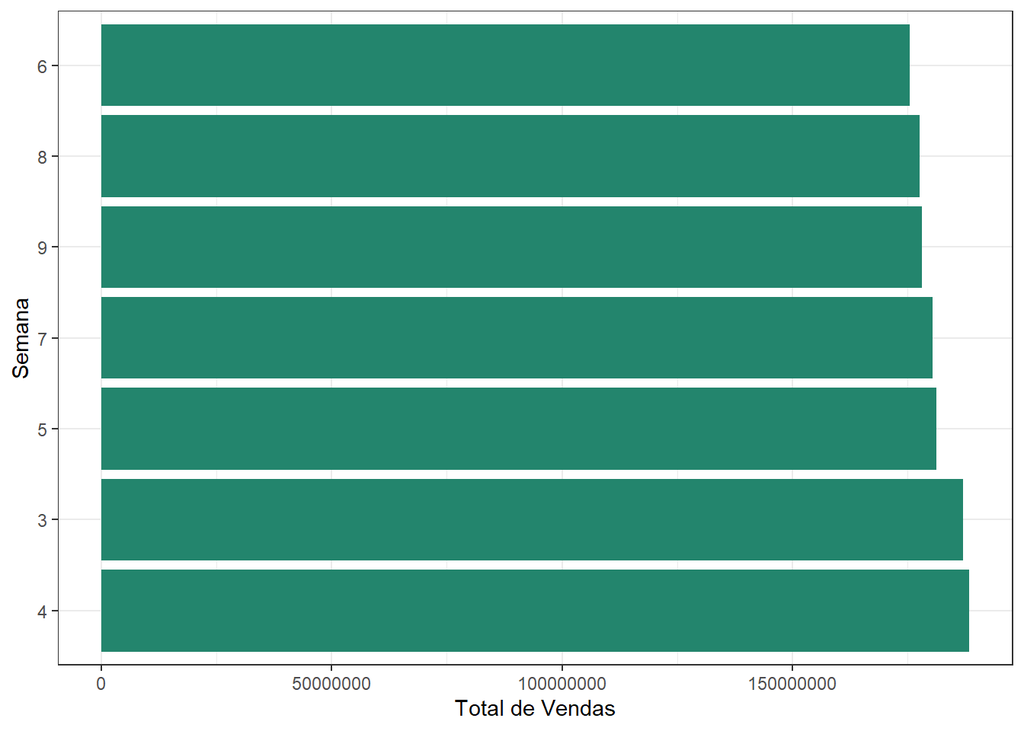

Podemos constatar que as semanas possuem uma quantidade similar de vendas, todas as semanas ficaram com aproximadamente 14% do total de vendas.

```r
# Analisando quantidade de vendas por canal de vendas
vendasT_bars(dados, 'Canal_ID' )
```

```
##    Canal_ID Uni_vendidas Total_vendas Percent_vendas
## 1:        1     97507943    783922376          61.83
## 2:        2     13063868    234503704          18.50
## 3:        4     11615337    117222318           9.25
## 4:        5      5231079     43377842           3.42
## 5:       11      3686681     41474754           3.27
## 6:        7      2576499     30197743           2.38
## 7:        8       747706      9560156           0.75
## 8:        6       893494      7175146           0.57
## 9:        9         9580       436793           0.03
```

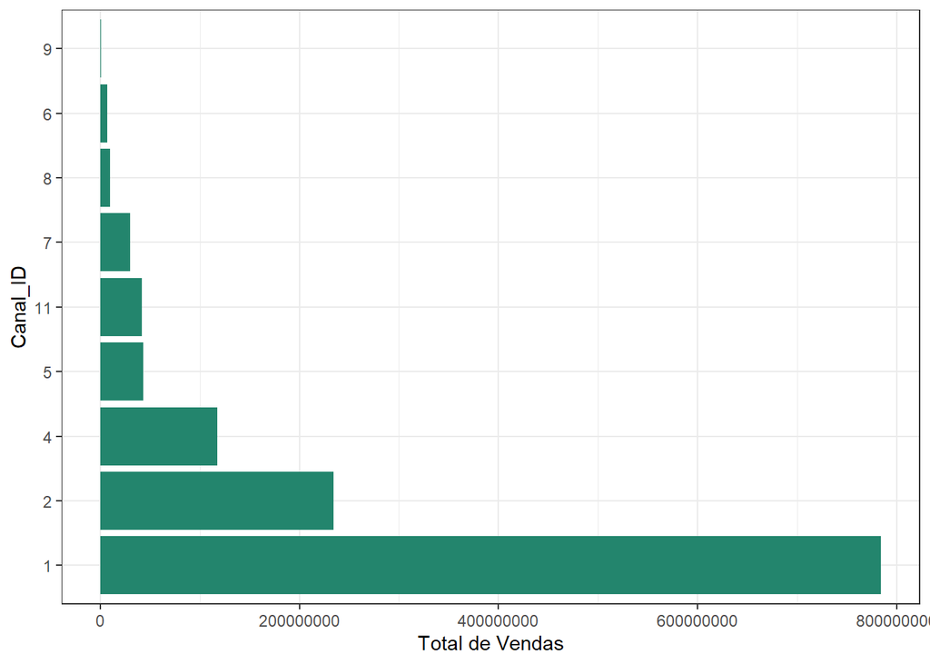

É visível a diferença entre o Canal 1 dos demais canais. Ele apresenta 61,83% do total de vendas, seguido do Canal 2 com um total de 18,50% do total de vendas.

```r
# Analisando quantidade de vendas por rota.
vendasT_bars(dados, 'Ruta_SAK')
```

```
##     Ruta_SAK Uni_vendidas Total_vendas Percent_vendas
##  1:     1001       487772      7706521           0.61
##  2:     1501       382329      7205162           0.57
##  3:     1003       419788      6589935           0.52
##  4:     1002       421772      6575700           0.52
##  5:     6601       635049      6530640           0.52
##  6:     1004       396198      6187426           0.49
##  7:     6602       579192      5992249           0.47
##  8:     6603       565111      5784982           0.46
##  9:     1005       363848      5641195           0.44
## 10:     1502       318403      5551209           0.44
```

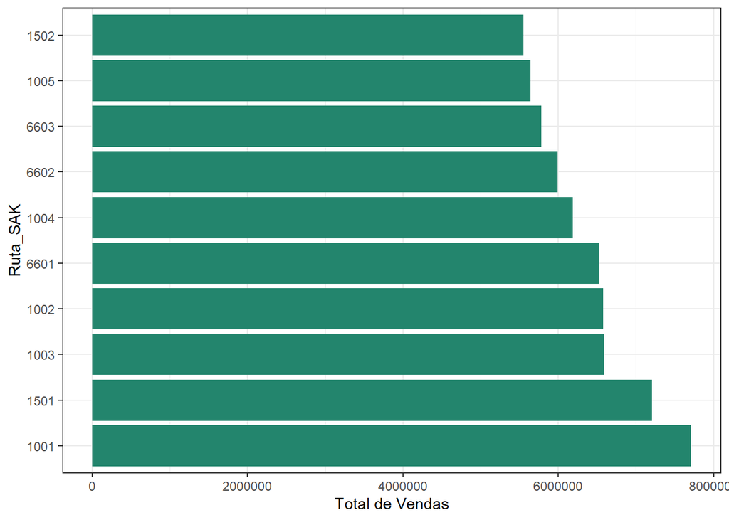

As rotas possuem um equilibrio na quantidade de vendas, nenhuma se sobressai. Contudo, como tivemos uma grande discrepância dos canais 1 e 2 dos demais canais, verificaremos as rotas que mais tiveram vendas por canal de vendas.

```r
# Analisando quantidade de vendas por rotas e canais de venda.
vendasT_bars(dados, 'Canal_ID', 'Ruta_SAK')
```

```
##     Canal_ID Ruta_SAK Uni_vendidas Total_vendas Percent_vendas
##  1:        1     1001       485393      7669624           0.60
##  2:        2     1501       354696      6736239           0.53
##  3:        1     1003       419573      6585799           0.52
##  4:        1     1002       419050      6535730           0.52
##  5:        4     6601       635049      6530640           0.52
##  6:        1     1004       394089      6155470           0.49
##  7:        4     6602       579192      5992249           0.47
##  8:        4     6603       557818      5707199           0.45
##  9:        1     1005       362032      5612014           0.44
## 10:        5     3001       631908      5240073           0.41
```

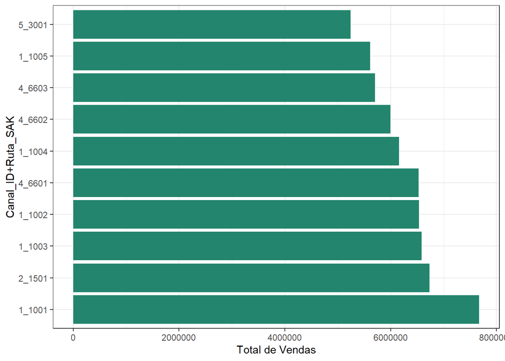

Podemos verificar que apenas a décima rota teve alteração com o subagrupamento nas rotas. Além disso, podemos concluir que a proporção de rotas do canal 1 é superior aos demais canais. Outro ponto interessante é que mesmo o Canal 2 apresentando 18,5% do total de vendas, o dobro do Canal 4, temos mais rotas do canal 4 entre as 10 primeiras rotas. Também é possível notar que a rota **1001** é a que possui maior quantidade de vendas e pertence ao Canal 1.

```r
# Analisando quantidade de vendas por cliente
vendasT_bars(dados, 'Nome_cliente')
```

```
##                                      Nome_cliente Uni_vendidas Total_vendas
##  1:                               PUEBLA REMISION      4701417   38975814.7
##  2:                 QUERETARO DE ARTEAGA REMISION       228338    1930220.3
##  3:                              JALISCO REMISION       127564    1054828.5
##  4:                 MC DONALDS ANTONIO CUAUTITLAN        10112     803040.0
##  5:                              CHEDRAUI POLANCO        46317     785218.1
##  6: WAL MART SUPER CENTER DOMINGO DIEZ CUERNAVACA        40296     737997.4
##  7:                              WAL MART TEPEYAC        41404     698610.5
##  8:                       OXXO TECNOLOGICO_175537        48730     697050.6
##  9:                   CEDIS CADENA COMERCIAL OXXO        44393     659363.0
## 10:                              SAMS CLUB TOLUCA        13565     616155.9
##     Percent_vendas
##  1:           3.07
##  2:           0.15
##  3:           0.08
##  4:           0.06
##  5:           0.06
##  6:           0.06
##  7:           0.06
##  8:           0.05
##  9:           0.05
## 10:           0.05
```

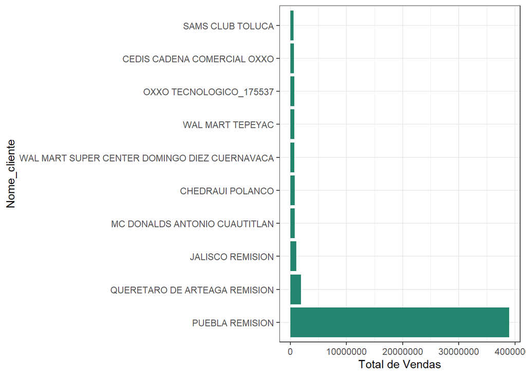

Claramente vemos que o cliente **PUEBLA REMISION** apresenta a maior quantidade de vendas: **3,07%**s do total ou **38.975.814** milhões de pesos. Vamos averiguar em qual semana esse cliente vendeu mais.

```r
# Analisando quantidade de vendas por cliente e semana.
vendasT_bars(dados, 'Nome_cliente', 'Semana')
```

```
##                      Nome_cliente Semana Uni_vendidas Total_vendas
##  1:               PUEBLA REMISION      4       703194    5810328.8
##  2:               PUEBLA REMISION      9       683554    5687355.2
##  3:               PUEBLA REMISION      7       681323    5649482.8
##  4:               PUEBLA REMISION      5       678424    5634528.4
##  5:               PUEBLA REMISION      8       674443    5600135.8
##  6:               PUEBLA REMISION      3       668726    5556495.6
##  7:               PUEBLA REMISION      6       611753    5037488.3
##  8: MC DONALDS ANTONIO CUAUTITLAN      3         4608     382694.4
##  9: QUERETARO DE ARTEAGA REMISION      6        34575     288256.5
## 10: MC DONALDS ANTONIO CUAUTITLAN      5         3456     287020.8
##     Percent_vendas
##  1:           0.46
##  2:           0.45
##  3:           0.45
##  4:           0.44
##  5:           0.44
##  6:           0.44
##  7:           0.40
##  8:           0.03
##  9:           0.02
## 10:           0.02
```

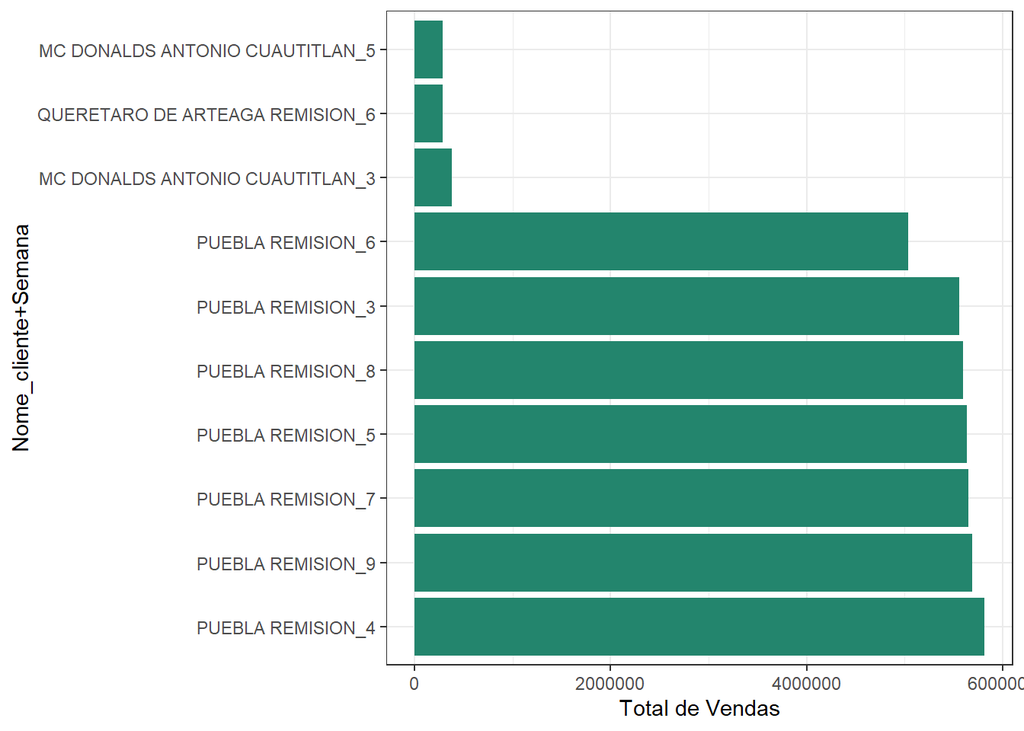

Aqui fica claro que o cliente **PUEBLA REMISION** é o que mais vendeu em todas as semanas. Vamos analisar agora quais as rotas os clientes mais utilizam e de quais ID’s são essas rotas.

```r
# Analisando quantidade de vendas por cliente, rota e canal de vendas.
vendasT_bars(dados, 'Nome_cliente', 'Ruta_SAK', 'Canal_ID')
```

```
##        Nome_cliente Ruta_SAK Canal_ID Uni_vendidas Total_vendas Percent_vendas
##  1: PUEBLA REMISION     3001        5       592787      4915855           0.39
##  2: PUEBLA REMISION     3002        5       530013      4401281           0.35
##  3: PUEBLA REMISION     3004        5       433763      3594542           0.28
##  4: PUEBLA REMISION     3003        5       412832      3407800           0.27
##  5: PUEBLA REMISION     3006        5       362950      3010967           0.24
##  6: PUEBLA REMISION     3005        5       327965      2700400           0.21
##  7: PUEBLA REMISION     3007        5       303759      2521944           0.20
##  8: PUEBLA REMISION     3008        5       214673      1791351           0.14
##  9: PUEBLA REMISION     3009        5       193752      1607335           0.13
## 10: PUEBLA REMISION     3010        5       193320      1601193           0.13
```

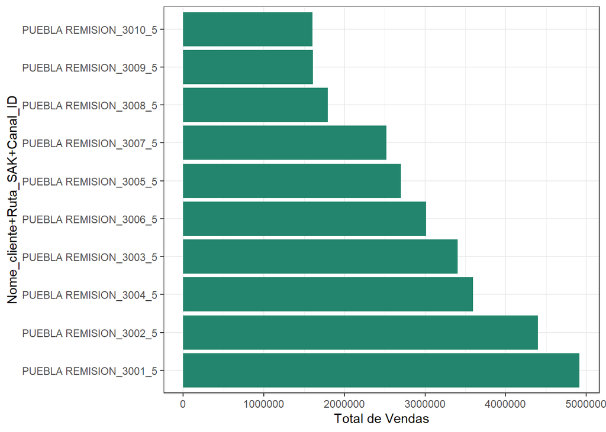

Podemos ver que o cliente **PUEBLA REMISION** utiliza mais as rotas do canal de vendas 5. Veremos agora, quais os canais que possuem mais venda por cliente e canal de vendas.

```r
# Analisando quantidade de vendas por cliente, canal de vendas.
vendasT_bars(dados, 'Nome_cliente', 'Canal_ID')
```

```
##                                      Nome_cliente Canal_ID Uni_vendidas
##  1:                               PUEBLA REMISION        5      4701417
##  2:                 QUERETARO DE ARTEAGA REMISION        5       228338
##  3:                              JALISCO REMISION        5       127564
##  4:                 MC DONALDS ANTONIO CUAUTITLAN        8        10112
##  5:                              CHEDRAUI POLANCO        2        46317
##  6: WAL MART SUPER CENTER DOMINGO DIEZ CUERNAVACA        2        40296
##  7:                              WAL MART TEPEYAC        2        41404
##  8:                       OXXO TECNOLOGICO_175537        4        48730
##  9:                   CEDIS CADENA COMERCIAL OXXO        4        44393
## 10:                              SAMS CLUB TOLUCA        2        13565
##     Total_vendas Percent_vendas
##  1:   38975814.7           3.07
##  2:    1930220.3           0.15
##  3:    1054828.5           0.08
##  4:     803040.0           0.06
##  5:     785218.1           0.06
##  6:     737997.4           0.06
##  7:     698610.5           0.06
##  8:     697050.6           0.05
##  9:     659363.0           0.05
## 10:     616155.9           0.05
```

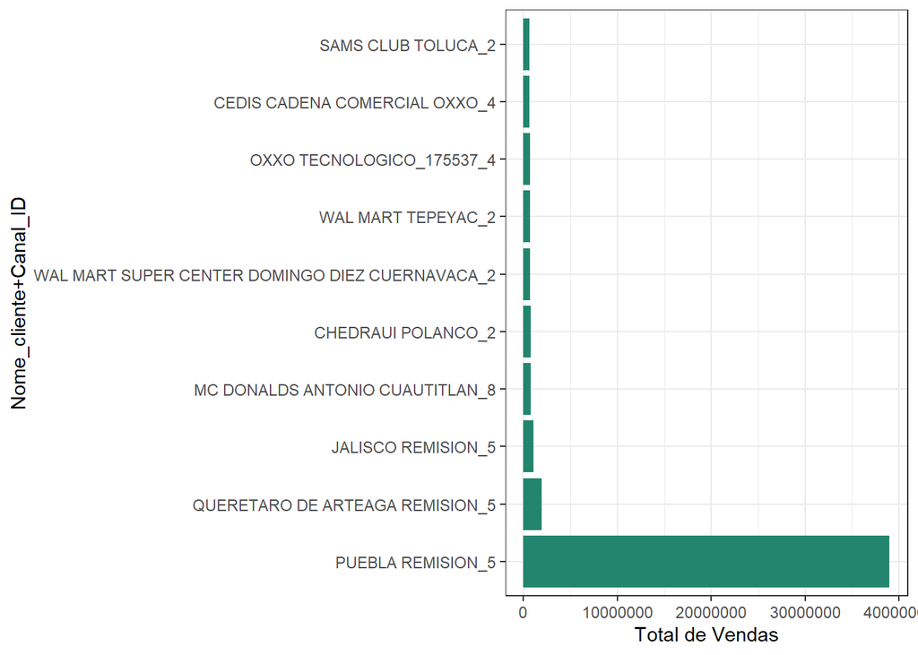

Vamos criar uma tabela a parte para nos auxiliar.

```r
# Tabela para verificar quantidade de clientes por canal de vendas.
dados[, .(Qntd_clientes = length(unique(Nome_cliente))), by = 'Canal_ID']
```

```
##    Canal_ID Qntd_clientes
## 1:        1        758905
## 2:        2          2902
## 3:        4         19634
## 4:        6          5977
## 5:        7         20999
## 6:       11         33616
## 7:        8          2042
## 8:        5           103
## 9:        9            28
```

Podemos constatar que o canal 5 possui apenas 103 clientes e é o canal que mais apresenta venda por cliente. Praticamente o total de vendas realizadas pelo canal 5 se dá pelos clientes **PUEBLA REMISION**, **QUERETARO DE ARTEAGA REMISION** E **JALISCO REMISION**. Também conseguimos constatar que o canal 1, sendo o canal com a maior quantidade de vendas, apresenta uma maior variabilidade de clientes e cada um vende uma quantia pequena.

Vejamos agora o total de venda por produto.

```r
# Analisando os 10 produtos mais vendidos.
vendasT_bars(dados, 'Produtos')
```

```
##                  Produtos Uni_vendidas Total_vendas Percent_vendas
##  1:            PAN BLANCO      5502030    109260278           8.62
##  2:          PAN INTEGRAL      4254221     87395055           6.89
##  3:                  NITO     14401648     65584774           5.17
##  4:           TORTILLINAS      4675402     57990269           4.57
##  5:         MEDIAS NOCHES      3017708     43795826           3.45
##  6:               GANSITO      6513104     34163262           2.69
##  7:   MANTECADAS VAINILLA      3579523     30593802           2.41
##  8:          DONAS AZUCAR      3379976     26286156           2.07
##  9:           PANQUE NUEZ      1358484     24859186           1.96
## 10: DONITAS ESPOLVOREADAS      3232246     24817464           1.96
```

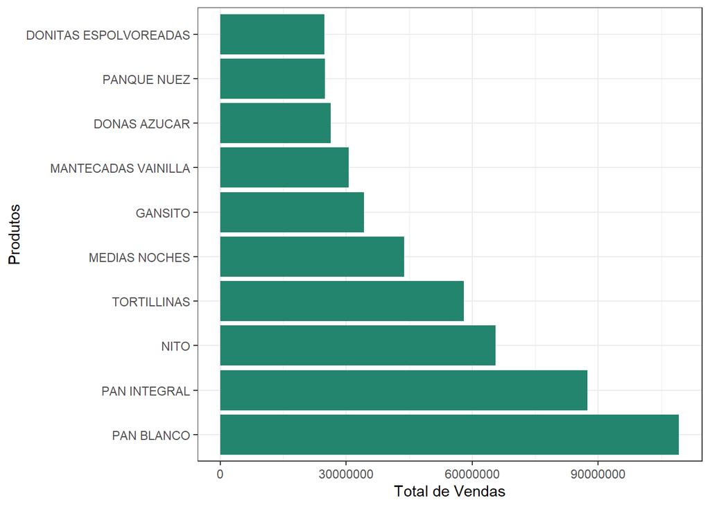

Podemos ver que os produtos possuem um percentual de vendas equilibrado, entretanto, **PAN BLANCO**, **PAN INTEGRAL** e **NITO**, são os três produtos mais consumidos.

Também é possível visualizarmos que o produto **NITO** possui **14.401.648** unidades vendidas, valor muito superior à todos os demais produtos. Isso nos ajuda a entender que o valor untiário desse produto é inferior aos demais.

Vejamos qual o maior valor de vendas dos produtos por clientes.

```r
# Analisando maior valor de vendas dos produtos por clientes.
vendasT_bars(dados, 'Nome_cliente', 'Produtos')
```

```
##        Nome_cliente            Produtos Uni_vendidas Total_vendas
##  1: PUEBLA REMISION      COCA COLA LATA       498677    4384412.2
##  2: PUEBLA REMISION        DONAS AZUCAR       225890    2089785.1
##  3: PUEBLA REMISION MANTECADAS VAINILLA       171011    1899942.7
##  4: PUEBLA REMISION      CHIPS JALAPENO       155583    1439866.0
##  5: PUEBLA REMISION           PINGUINOS       141991    1312888.0
##  6: PUEBLA REMISION            DUO NITO       129287    1197197.6
##  7: PUEBLA REMISION           DORADITAS       113691    1067615.3
##  8: PUEBLA REMISION           CHIPOTLES       115041     972620.6
##  9: PUEBLA REMISION  TOSTACHOS QUESO CB       113301     958597.1
## 10: PUEBLA REMISION           CANELITAS       145702     948048.6
##     Percent_vendas
##  1:           0.35
##  2:           0.16
##  3:           0.15
##  4:           0.11
##  5:           0.10
##  6:           0.09
##  7:           0.08
##  8:           0.08
##  9:           0.08
## 10:           0.07
```

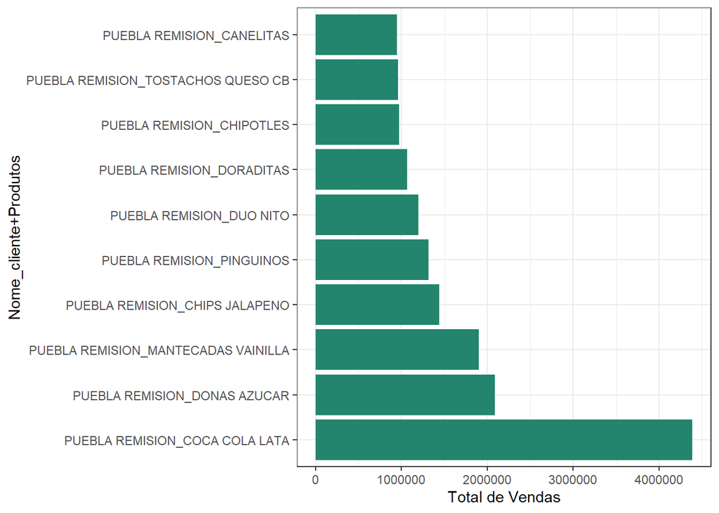

Podemos ver que os 10 produtos mais vendidos são de um único cliente: **PUEBLA REMISION**. E a Coca-cola lata é o produto mais vendido.

Analiseremos o maior valor de venda dos produtos por semana.

```r
# Analisando maior valor de venda dos produtos por semana.
vendasT_bars(dados, 'Produtos', 'Semana')
```

```
##         Produtos Semana Uni_vendidas Total_vendas Percent_vendas
##  1:   PAN BLANCO      3       845634     16839172           1.33
##  2:   PAN BLANCO      4       797808     15845763           1.25
##  3:   PAN BLANCO      9       789007     15608117           1.23
##  4:   PAN BLANCO      8       785406     15605371           1.23
##  5:   PAN BLANCO      7       768923     15308660           1.21
##  6:   PAN BLANCO      5       760321     15083069           1.19
##  7:   PAN BLANCO      6       754931     14970126           1.18
##  8: PAN INTEGRAL      9       635894     13027485           1.03
##  9: PAN INTEGRAL      8       622156     12781032           1.01
## 10: PAN INTEGRAL      3       605807     12468613           0.98
```

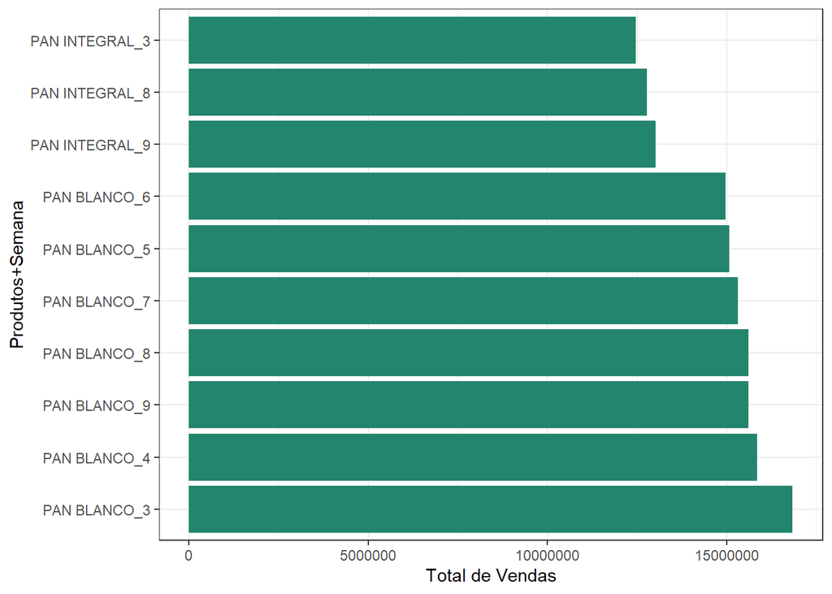

Em todas as semanas o **PAN BLANCO** foi o produto mais vendido seguido do **PAN INTEGRAL**. Além disso, podemos ver que o seu percentual de vendas varia bem pouco entre as semanas.

Vejamos o maior valor de venda dos produtos por canal.

```r
# Analisando maior valor de venda dos produtos por canal.
vendasT_bars(dados, 'Produtos', 'Canal_ID')
```

```
##                  Produtos Canal_ID Uni_vendidas Total_vendas Percent_vendas
##  1:            PAN BLANCO        1      3210882     63788852           5.03
##  2:                  NITO        1     13230084     59791405           4.72
##  3:          PAN INTEGRAL        1      2484466     49947497           3.94
##  4:           TORTILLINAS        1      3135252     36842336           2.91
##  5:            PAN BLANCO        2      1366878     27365553           2.16
##  6:               GANSITO        1      5160480     27271789           2.15
##  7:         MEDIAS NOCHES        1      1689963     23708695           1.87
##  8:   MANTECADAS VAINILLA        1      2818229     23658455           1.87
##  9:          PAN INTEGRAL        2      1118594     23631238           1.86
## 10: DONITAS ESPOLVOREADAS        1      2760853     21163699           1.67
```

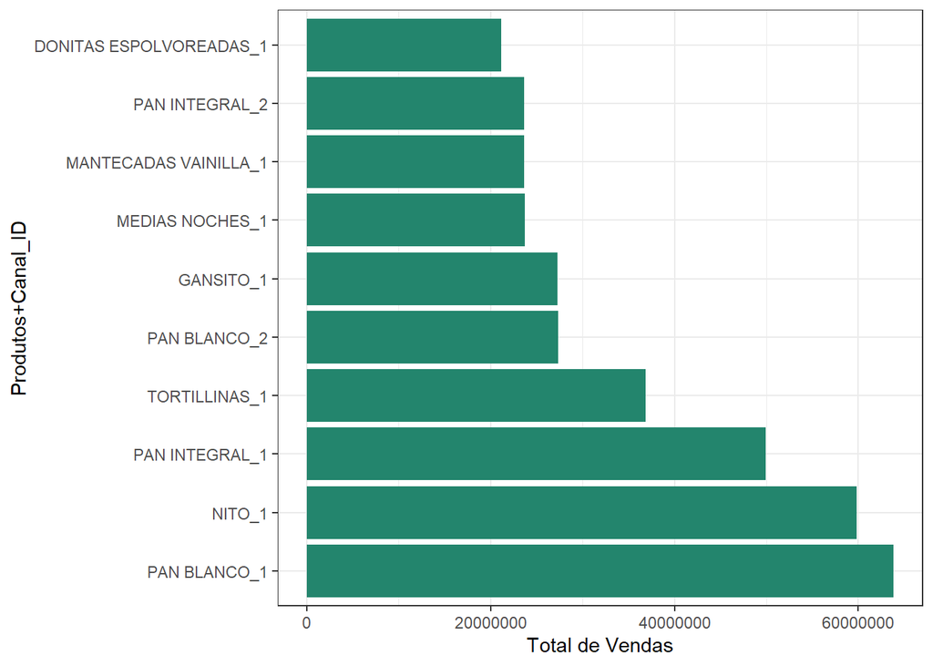

Vejamos o maior valor de venda por fabricante.

```r
# Analisando maior valor de venda por fabricante..
vendasT_bars(dados, 'Fabricante')
```

```
##     Fabricante Uni_vendidas Total_vendas Percent_vendas
##  1:        BIM     72002975    758124733          59.80
##  2:        MLA     37186743    242452156          19.12
##  3:         TR     13671738    109367808           8.63
##  4:        WON      1929993     36019317           2.84
##  5:         DH      2382253     23904497           1.89
##  6:        LAR      2024839     16656583           1.31
##  7:         MR      1017614     14910877           1.18
##  8:        ORO       419283     12602665           0.99
##  9:        BAR      1190892     10063958           0.79
## 10:         SL       315195      9675466           0.76
```

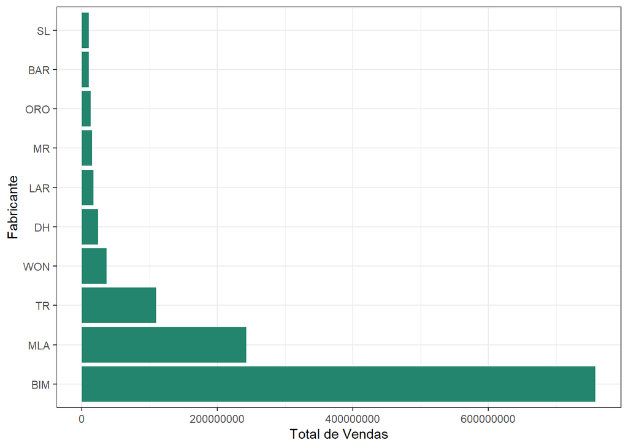

Podemos ver claramente que o fabricante **BIM** se destaca amplamento dos demais, possui 59,8% das vendas. Seguido dele vem o fabricante **MLA** com 19,12% das vendas.

Vejamos o maior valor de venda de produtos por fabricante.

```r
# Produtos o maior valor de venda de produtos por fabricante.
vendasT_bars(dados, 'Fabricante', 'Produtos')
```

```
##     Fabricante              Produtos Uni_vendidas Total_vendas Percent_vendas
##  1:        BIM            PAN BLANCO      5239620    105164421           8.29
##  2:        BIM          PAN INTEGRAL      4248451     87297192           6.89
##  3:        BIM                  NITO     14401648     65584774           5.17
##  4:         TR           TORTILLINAS      4675402     57990269           4.57
##  5:        BIM         MEDIAS NOCHES      3014849     43680736           3.45
##  6:        MLA               GANSITO      6513104     34163262           2.69
##  7:        BIM   MANTECADAS VAINILLA      3579523     30593802           2.41
##  8:        BIM          DONAS AZUCAR      3379976     26286156           2.07
##  9:        BIM           PANQUE NUEZ      1358484     24859186           1.96
## 10:        BIM DONITAS ESPOLVOREADAS      3232246     24817464           1.96
```

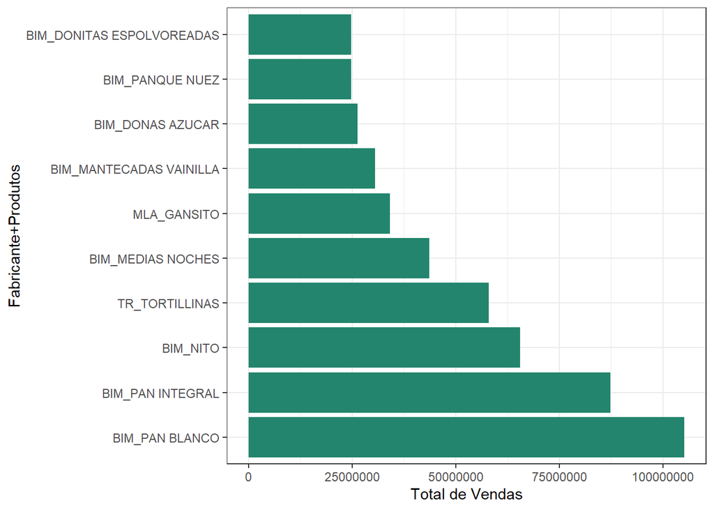

Podemos ver que 8 dos 10 produtos mais vendidos são do fabricante **BIM**.

Analisaremos agora os maior valor de venda de produtos por fabricante por semana.

```r
# Produtos mais vendidos por fabricante por semana.
vendasT_bars(dados, 'Fabricante', 'Produtos', 'Semana')
```

```
##     Fabricante     Produtos Semana Uni_vendidas Total_vendas Percent_vendas
##  1:        BIM   PAN BLANCO      3       809372     16266548           1.28
##  2:        BIM   PAN BLANCO      4       759528     15248851           1.20
##  3:        BIM   PAN BLANCO      9       749227     14988220           1.18
##  4:        BIM   PAN BLANCO      8       743501     14955150           1.18
##  5:        BIM   PAN BLANCO      7       734297     14768121           1.16
##  6:        BIM   PAN BLANCO      5       728060     14580497           1.15
##  7:        BIM   PAN BLANCO      6       715635     14357033           1.13
##  8:        BIM PAN INTEGRAL      9       635065     13013322           1.03
##  9:        BIM PAN INTEGRAL      8       620895     12759675           1.01
## 10:        BIM PAN INTEGRAL      3       605403     12461815           0.98
```

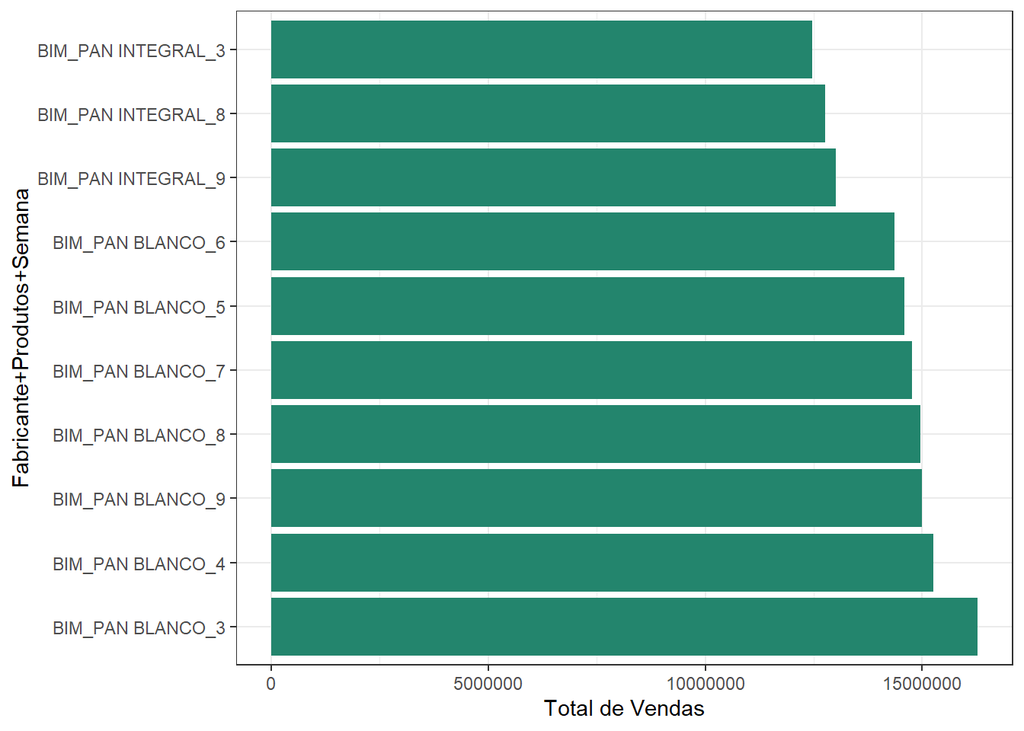

Em todas as semenas todos o produto mais vendido pertence ao fabricante **BIM**.

Vejamos o maior valor de venda de produtos por fabricante por cliente.

```r
# Maior valor de venda de produtos por fabricante por cliente.
vendasT_bars(dados, 'Fabricante', 'Produtos', 'Nome_cliente')
```

```
##     Fabricante            Produtos    Nome_cliente Uni_vendidas Total_vendas
##  1:         CC      COCA COLA LATA PUEBLA REMISION       498677    4384412.2
##  2:        BIM        DONAS AZUCAR PUEBLA REMISION       225890    2089785.1
##  3:        BIM MANTECADAS VAINILLA PUEBLA REMISION       171011    1899942.7
##  4:        BAR      CHIPS JALAPENO PUEBLA REMISION       155583    1439866.0
##  5:        MLA           PINGUINOS PUEBLA REMISION       141991    1312888.0
##  6:        BIM            DUO NITO PUEBLA REMISION       129287    1197197.6
##  7:         TR           DORADITAS PUEBLA REMISION       113691    1067615.3
##  8:        BAR           CHIPOTLES PUEBLA REMISION       115041     972620.6
##  9:        BAR  TOSTACHOS QUESO CB PUEBLA REMISION       113301     958597.1
## 10:        MLA           CANELITAS PUEBLA REMISION       145702     948048.6
##     Percent_vendas
##  1:           0.35
##  2:           0.16
##  3:           0.15
##  4:           0.11
##  5:           0.10
##  6:           0.09
##  7:           0.08
##  8:           0.08
##  9:           0.08
## 10:           0.07
```

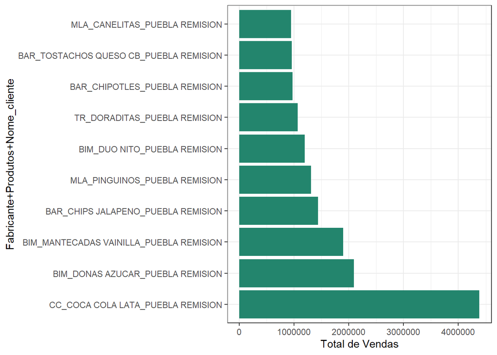

Podemos ver que todos os produtos mais vendidos são vendidos pelo cliente **PUEBLA REMISION** e que o produto mais vendido é a Coca Cola, do fabricante **CC**.

Também é possível ver que mesmo o fabricante **BIM** sendo o fabricante que mais vendeu e que 8 dos 10 produtos mais vendidos são dele, aqui percebemos que o cliente **PUEBLA REMISION** possui uma boa quantidade de vendas de produtos de diversos fabricantes.

Vejamos agora o maior valor de venda por cidade.

```r
# Analisando quantidade de vendas por cidade
vendasT_bars(dados, 'Cidade')
```

```
##                        Cidade Uni_vendidas Total_vendas Percent_vendas
##  1:               SAN ANTONIO      2522109     31530209           2.49
##  2:            MEGA NAUCALPAN      2279247     27435767           2.16
##  3:              IZTAPALAPA 2      1722212     23258940           1.83
##  4:          GRANJAS MARINELA      1153523     13113169           1.03
##  5:                    CEYLAN      1433108     12370821           0.98
##  6:             RUIZ CORTINEZ      1052257     11925933           0.94
##  7: SANTA CLARA AUTOSERVICIOS       660417     11618054           0.92
##  8:                 TULTITLAN      1197203     11354874           0.90
##  9:       TIJUANA GATO BRONCO       916833     11217896           0.88
## 10:      AGUASCALIENTES NORTE      1258307     10990374           0.87
```

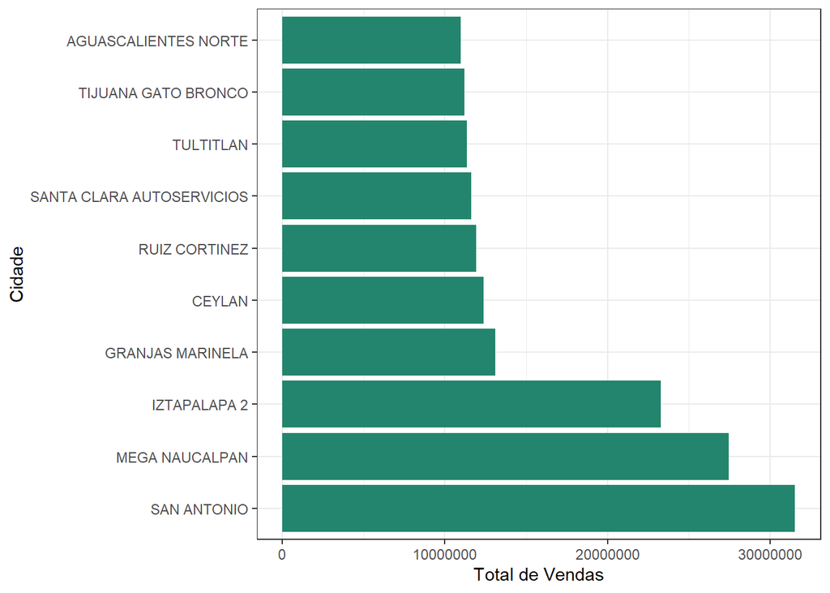

As cidades possuem um bom equilíbrio de vendas entre elas, porém **SAN ANTONIO** , **MEGA NAUCALPAN** e **IZTAPALAPA 2** são as cidades com um pequeno destaque.

Vejamos o total de vendas das cidades por estado.

```r
# Analisando quantidade de vendas das cidades por estado.
vendasT_bars(dados, 'Cidade', 'Estado')
```

```
##                        Cidade                Estado Uni_vendidas Total_vendas
##  1:               SAN ANTONIO          MÉXICO, D.F.      2522109     31530209
##  2:            MEGA NAUCALPAN      ESTADO DE MÉXICO      2279247     27435767
##  3:              IZTAPALAPA 2          MÉXICO, D.F.      1722212     23258940
##  4:          GRANJAS MARINELA               JALISCO      1153523     13113169
##  5:                    CEYLAN          MÉXICO, D.F.      1433108     12370821
##  6:             RUIZ CORTINEZ               TABASCO      1052257     11925933
##  7: SANTA CLARA AUTOSERVICIOS      ESTADO DE MÉXICO       660417     11618054
##  8:                 TULTITLAN      ESTADO DE MÉXICO      1197203     11354874
##  9:       TIJUANA GATO BRONCO BAJA CALIFORNIA NORTE       916833     11217896
## 10:      AGUASCALIENTES NORTE        AGUASCALIENTES      1258307     10990374
##     Percent_vendas
##  1:           2.49
##  2:           2.16
##  3:           1.83
##  4:           1.03
##  5:           0.98
##  6:           0.94
##  7:           0.92
##  8:           0.90
##  9:           0.88
## 10:           0.87
```

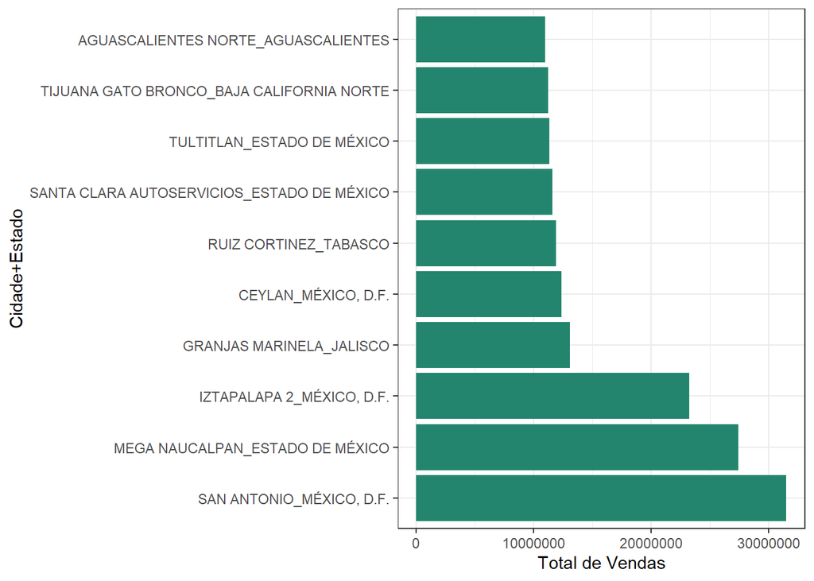

Duas das três cidades com maior quantidade de vendas percentem ao distrito federal do México.

Analisaremos qual maior valor de venda de produtos por cidade.

```r
# Maior valor de venda de produtos por cidade.
vendasT_bars(dados, 'Cidade', 'Produtos')
```

```
##             Cidade         Produtos Uni_vendidas Total_vendas Percent_vendas
##  1:    SAN ANTONIO       PAN BLANCO       119331      2367440           0.19
##  2:    SAN ANTONIO     PAN INTEGRAL       109776      2246910           0.18
##  3:    SAN ANTONIO      TORTILLINAS       156084      2115080           0.17
##  4: MEGA NAUCALPAN       PAN BLANCO       101838      2074404           0.16
##  5:         JUAREZ BOLLOS EXTRA AJN        66834      1851249           0.15
##  6:   IZTAPALAPA 2     PAN INTEGRAL        87446      1830438           0.14
##  7: MEGA NAUCALPAN      TORTILLINAS       133939      1824726           0.14
##  8: MEGA NAUCALPAN     PAN INTEGRAL        84629      1735906           0.14
##  9:   IZTAPALAPA 2       PAN BLANCO        84900      1637181           0.13
## 10:  RUIZ CORTINEZ       PAN BLANCO        81319      1636588           0.13
```

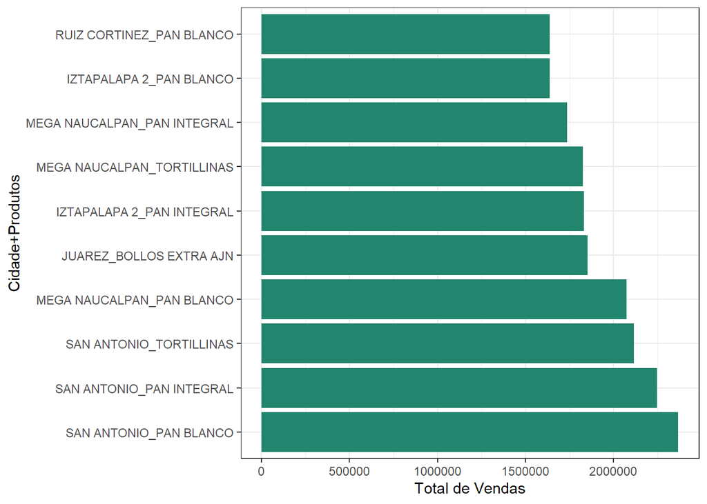

Podemos ver que os três produtos mais vendidos são da cidade de **SAN ANTONIO**.

Vejamos agora quais os clientes com maior valor de venda por cidade.

```r
# Cliente que mais vendem por cidade.
vendasT_bars(dados, 'Cidade', 'Nome_cliente')
```

```
##                    Cidade                  Nome_cliente Uni_vendidas
##  1:                CEYLAN               PUEBLA REMISION       384568
##  2:     TOLUCA AEROPUERTO               PUEBLA REMISION       275374
##  3:             TULTITLAN               PUEBLA REMISION       268255
##  4:        MEGA NAUCALPAN               PUEBLA REMISION       235766
##  5:   QUERETARO BALVANERA QUERETARO DE ARTEAGA REMISION       228338
##  6:          TEPALCATES 1               PUEBLA REMISION       180210
##  7:          IZTAPALAPA 2               PUEBLA REMISION       161763
##  8: PUEBLA NORTE MARINELA               PUEBLA REMISION       161554
##  9:         LEON MILENIUM               PUEBLA REMISION       160163
## 10:                JUAREZ               PUEBLA REMISION       136157
##     Total_vendas Percent_vendas
##  1:      3200232           0.25
##  2:      2288377           0.18
##  3:      2234160           0.18
##  4:      1972450           0.16
##  5:      1930220           0.15
##  6:      1484991           0.12
##  7:      1324830           0.10
##  8:      1321564           0.10
##  9:      1316171           0.10
## 10:      1105099           0.09
```

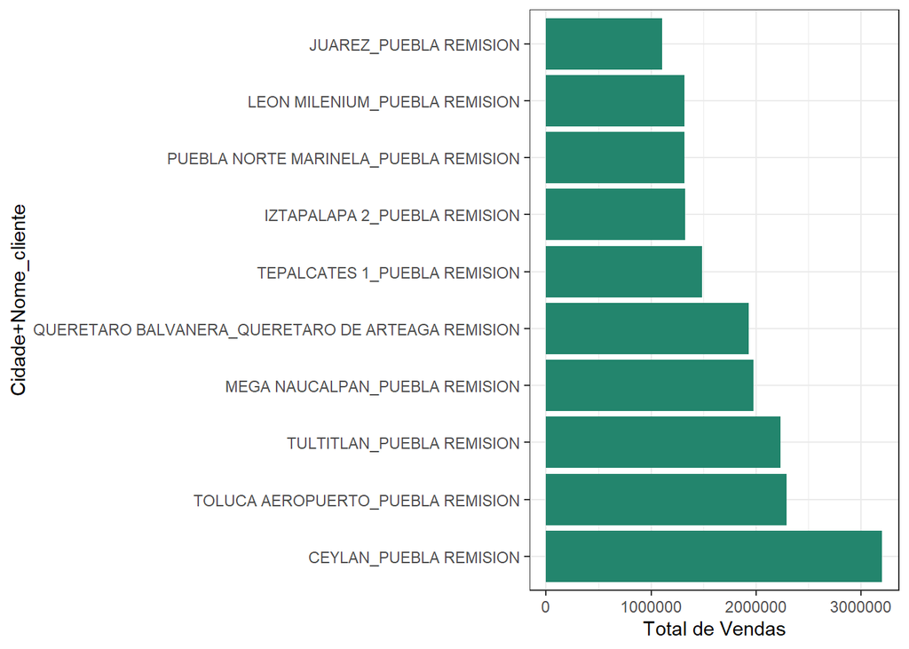

Podemos inferir que o cliente **PUEBLA REMISION** é uma rede e possui várias unidades por todo o México e é o cliente que mais venda em 9 das 10 cidades que mais venderam.

Vejamos quais cidades mais venderam por semana.

```r
# Cidades que mais venderam por semana.
vendasT_bars(dados, 'Cidade', 'Semana')
```

```
##             Cidade Semana Uni_vendidas Total_vendas Percent_vendas
##  1:    SAN ANTONIO      4       386770      4859533           0.38
##  2:    SAN ANTONIO      3       372703      4679618           0.37
##  3:    SAN ANTONIO      7       363609      4573530           0.36
##  4:    SAN ANTONIO      9       369141      4466579           0.35
##  5:    SAN ANTONIO      8       361457      4456996           0.35
##  6:    SAN ANTONIO      6       340373      4343047           0.34
##  7:    SAN ANTONIO      5       328056      4150907           0.33
##  8: MEGA NAUCALPAN      4       342260      4147613           0.33
##  9: MEGA NAUCALPAN      6       325234      4050952           0.32
## 10: MEGA NAUCALPAN      3       321755      3925078           0.31
```

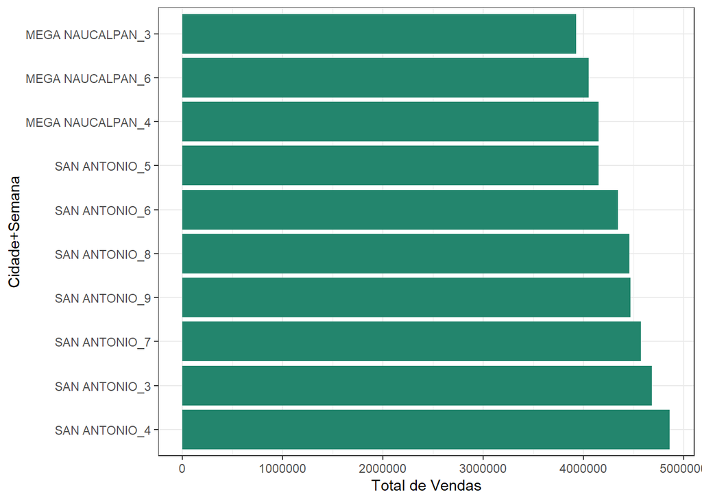

A cidade de **SAN ANTONIO** foi a cidade que mais vendeu em todas as semanas, seguida da cidade **MEGA NAUCALPAN**.

Vamos analisar os fabricantes que mais venderam por cidade.

```r
# Fabricantes que mais venderam por cidade.
vendasT_bars(dados, 'Cidade', 'Fabricante')
```

```
##                        Cidade Fabricante Uni_vendidas Total_vendas
##  1:               SAN ANTONIO        BIM      1179351     16684964
##  2:            MEGA NAUCALPAN        BIM      1115679     14984901
##  3:              IZTAPALAPA 2        BIM       874523     13131123
##  4:          GRANJAS MARINELA        BIM       660334      7960703
##  5:                     NORTE        BIM       829344      7030885
##  6:               SANTA CLARA        BIM       742658      6918614
##  7:       TIJUANA GATO BRONCO        BIM       470194      6858307
##  8:             RUIZ CORTINEZ        BIM       515322      6724964
##  9: SANTA CLARA AUTOSERVICIOS        BIM       360283      6599336
## 10:                  XALOSTOC        BIM       672423      6598437
##     Percent_vendas
##  1:           1.32
##  2:           1.18
##  3:           1.04
##  4:           0.63
##  5:           0.55
##  6:           0.55
##  7:           0.54
##  8:           0.53
##  9:           0.52
## 10:           0.52
```

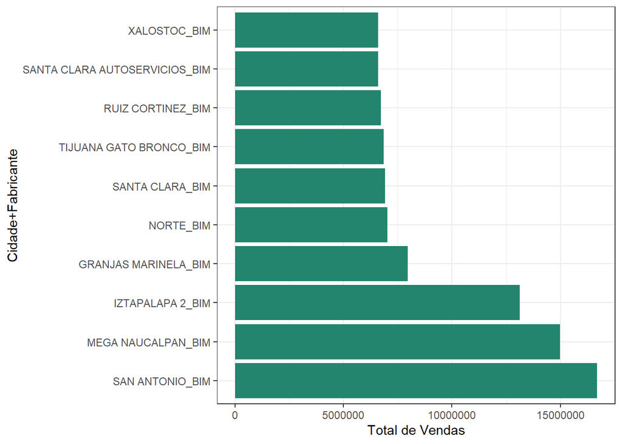

Podemos ver que o fabricante **BIM** foi o que mais vendeu nas 10 primeiras cidades.

Vejamos quais foram as rotas que mais venderam por cidade.

```r
# Rotas que mais vederam por cidade.
vendasT_bars(dados, 'Cidade', 'Ruta_SAK')
```

```
##                           Cidade Ruta_SAK Uni_vendidas Total_vendas
##  1: AZCAPOTZALCO INSTITUCIONALES     3601        10112     803040.0
##  2:               MEGA NAUCALPAN        3        46161     781076.1
##  3:    SANTA CLARA AUTOSERVICIOS        1        38400     633087.4
##  4:                 IZTAPALAPA 2        8        30648     509380.3
##  5:                 IZTAPALAPA 2       38        29700     490590.4
##  6:                  SAN ANTONIO       60        27149     480499.8
##  7:                  SAN ANTONIO       15        26383     475553.0
##  8:                    CANCUN II     1502        26091     455356.8
##  9:                 IZTAPALAPA 2       52        25513     431191.9
## 10:                 IZTAPALAPA 2       16        11923     429383.5
##     Percent_vendas
##  1:           0.06
##  2:           0.06
##  3:           0.05
##  4:           0.04
##  5:           0.04
##  6:           0.04
##  7:           0.04
##  8:           0.04
##  9:           0.03
## 10:           0.03
```

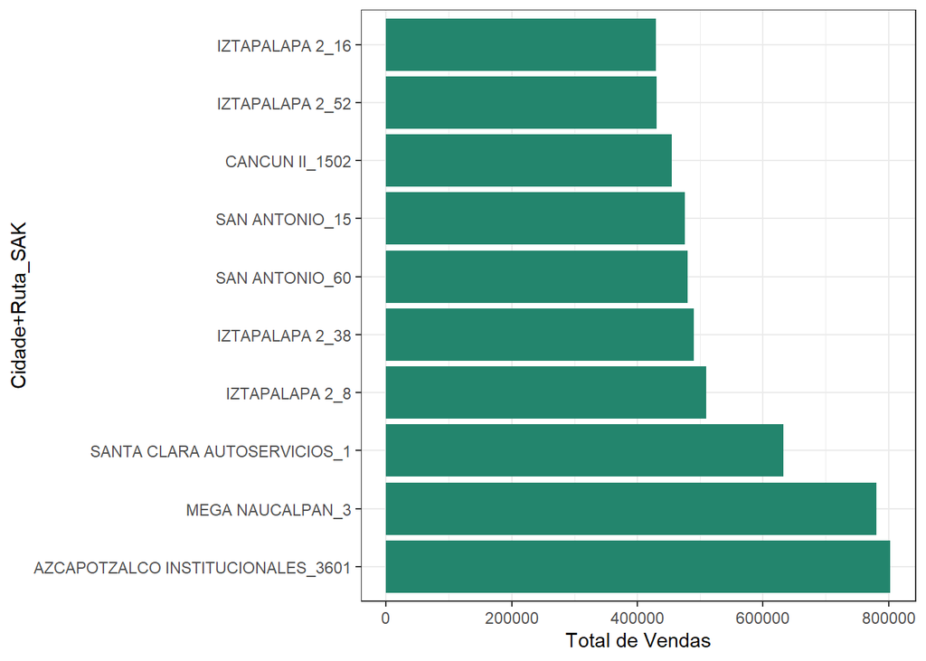

Cada rota possui uma pequena parcela do total de vendas e nenhuma rota é usada por mais de uma cidade entre as 10 primeiras cidades.

Vejamos quais foram os pesos de produtos com maior valor de venda.

```r
# Pesos com maior valor de venda.
vendasT_bars(dados, 'Peso')
```

```
##     Peso Uni_vendidas Total_vendas Percent_vendas
##  1: 640g      3649189     73534816           5.80
##  2:  62g     14589983     67064818           5.29
##  3: 105g      8411061     65638032           5.18
##  4: 680g      2773019     63494462           5.01
##  5: 255g      4393273     59479325           4.69
##  6: 340g      3174102     44350890           3.50
##  7: 675g      1968305     42323872           3.34
##  8:  50g      7775152     40696541           3.21
##  9:  80g      5210184     39341277           3.10
## 10: 210g      3259389     36412582           2.87
```

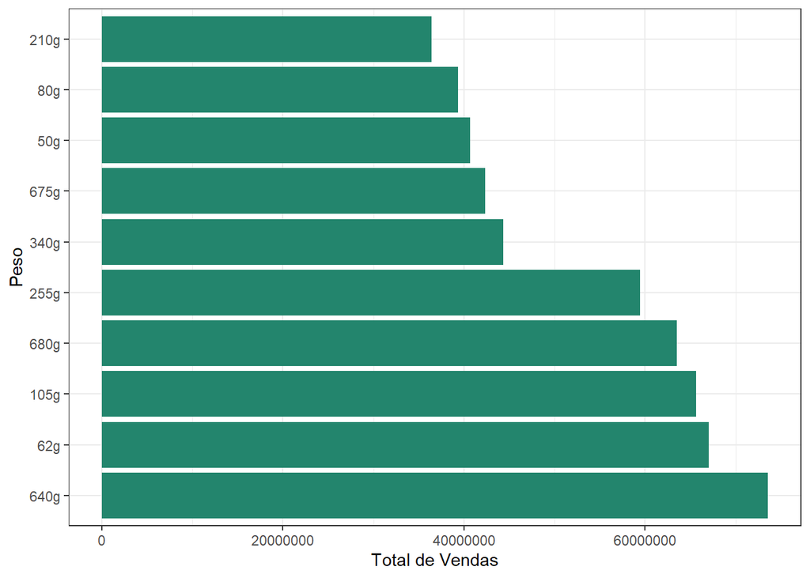

Vejamos os pesos com maior valor de venda por produto.

```r
# Pesos com maior valor de venda por produto.
vendasT_bars(dados, 'Peso', 'Produtos')
```

```
##     Peso              Produtos Uni_vendidas Total_vendas Percent_vendas
##  1: 640g            PAN BLANCO      3306169     65839461           5.19
##  2:  62g                  NITO     14399942     65514725           5.17
##  3: 675g          PAN INTEGRAL      1927813     41232160           3.25
##  4: 340g         MEDIAS NOCHES      2681952     37991572           3.00
##  5:  50g               GANSITO      6513104     34163262           2.69
##  6: 125g   MANTECADAS VAINILLA      3578302     30564315           2.41
##  7: 105g          DONAS AZUCAR      3376796     26207039           2.07
##  8: 680g          PAN INTEGRAL      1114351     25114110           1.98
##  9: 255g           PANQUE NUEZ      1358484     24859186           1.96
## 10: 105g DONITAS ESPOLVOREADAS      3232098     24812870           1.96
```

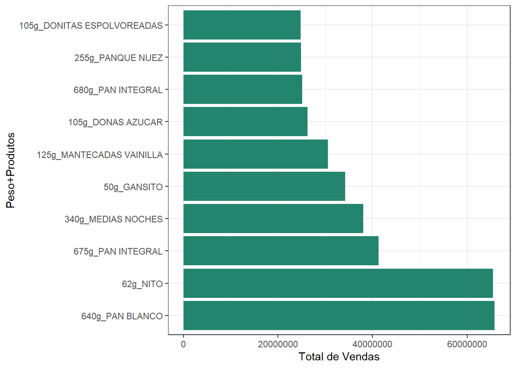

Analisaremos agora as variáveis quantitativas. Criaremos histogramas para avaliarmos as distribuições de cada variável. Criaremos um objeto contendo apenas as colunas numéricas de nossos dados para criarmos os histogramas.

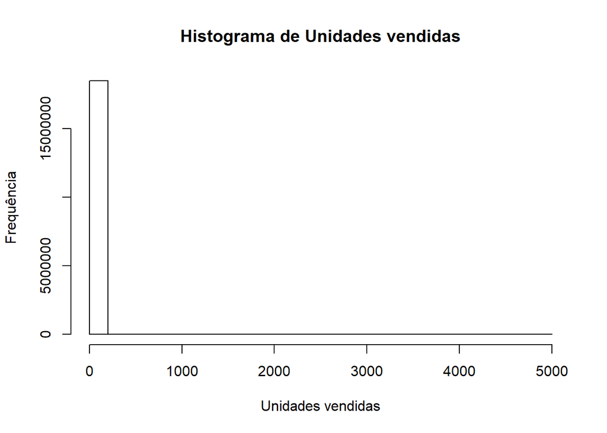

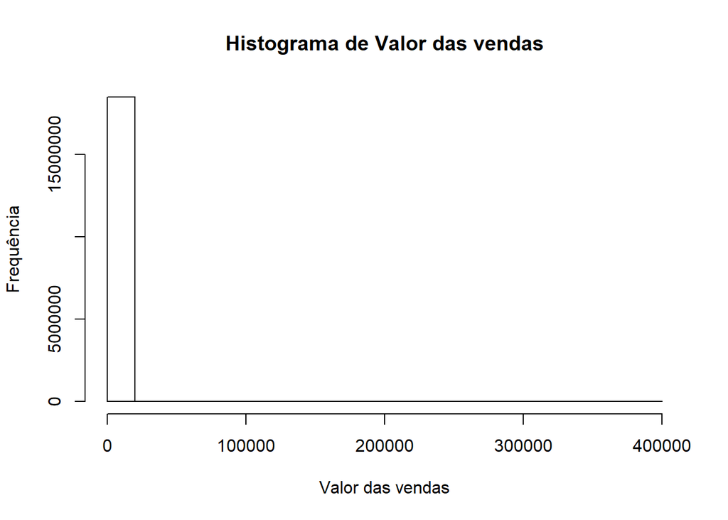

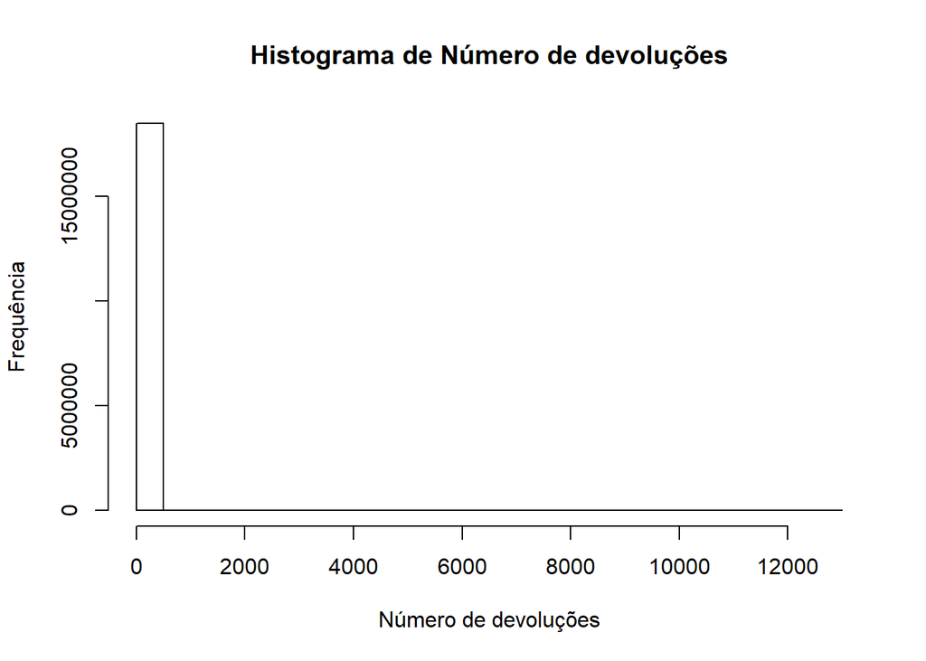

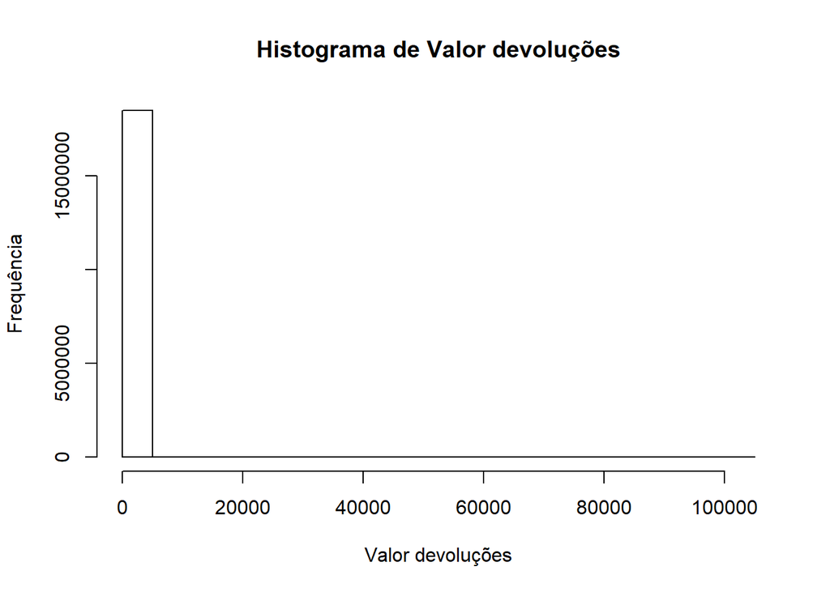

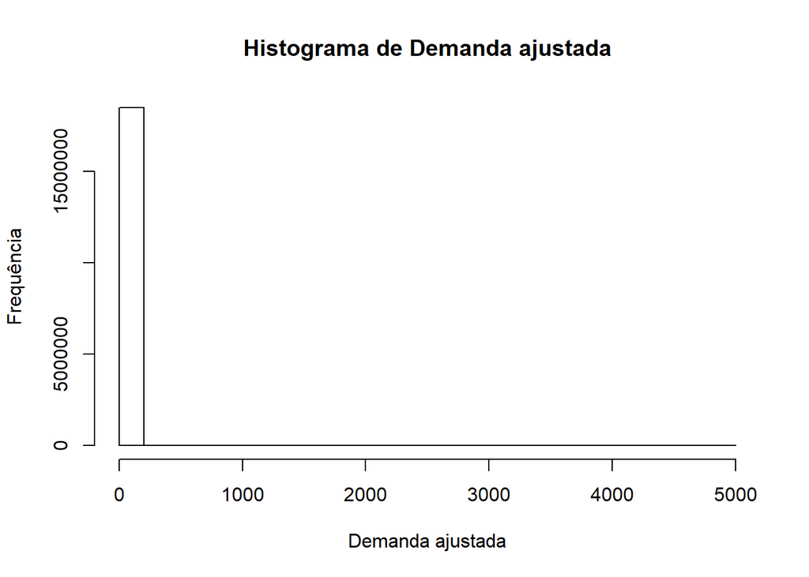

```r
# Criando uma variável com colunas numéricas.
numericas <- sapply(dados, is.numeric)

# Criando um objeto para título e legenda do eixo x.
titulos <- c('Unidades vendidas', 'Valor das vendas', 'Número de devoluções', 'Valor devoluções', 'Demanda ajustada')

# Criando a função para histograma.
meu_hist <- function(coluna, titulo){

  hist(coluna, main = paste('Histograma de ', titulo, sep = ''), xlab = titulo, ylab = 'Frequência')

}

# Criando histogramas para as variáveis quantitativas.
Map(meu_hist, dados[, numericas, with = F], titulos)
```

Como podemos ver a maior parte as observaçoes em todas as variáveis são de valores muito baixos. Aparentemente essas variáveis são todas a assimétricas. Validaremos a informaçõ verificando o coeficiente de Assimetria e Curtose.

#### *Coeficiente de assimetria*:

O coeficiente de assimetria é o que nos permite dizer se uma determinada distribuição é assimétrica ou não.

- Sk = 0: dados simétricos. Tanto a cauda do lado direito quanto a do lado esquerdo da função densidade de probabilidade são iguais.
- Sk < 0: assimetria negativa. A cauda do lado esquerdo da função densidade de probabilidade é maior que a do lado direito.
- Sk > 0: assimetria positiva. A cauda do lado direito da função densidade de probabilidade é maior que a do lado esquerdo.

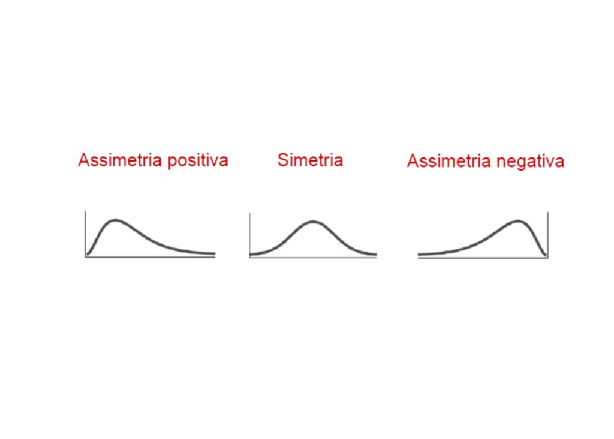

#### *Coeficiente de Curtose*:

O coeficiente de curtose é uma medida que caracteriza o achatamento da curva da função de distribuição.

- CK ≈ 0: Distribuição normal. Chamada de Curtose Mesocúrtica.
- CK < 0: Cauda mais leve que a normal. Para um coeficiente de Curtose negativo, tem-se uma Curtose Platicúrtica.
- CK > 0: Cauda mais pesada que a normal. Para um coeficiente de Curtose positivo, tem-se uma Curtose Leptocúrtica.

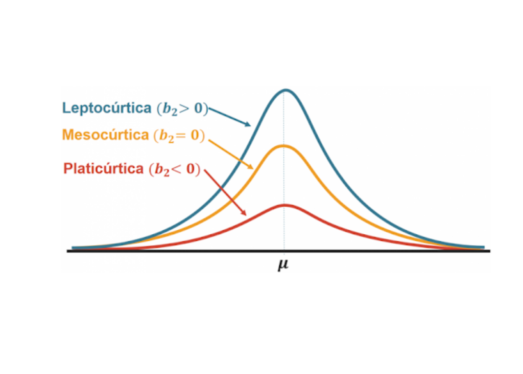

```r
# verificando o Coeficiente de Assimetria e Curtose.
data.frame(Assimetria = sapply(dados[, numericas, with=F], function(coluna){
  skewness(coluna)}),
  Kurtose = sapply(dados[, numericas, with=F], function(coluna){
    kurtosis(coluna)}))
```

```
##                   Assimetria     Kurtose
## Venta_uni_hoy       42.23285    4707.959
## Venta_hoy          188.19364  159073.145
## Dev_uni_proxima   1582.59365 3911682.320
## Dev_proxima       1192.29942 2349578.634
## Demanda_uni_equil   42.65262    4808.632
```

Como vimos, em todas as variáveis tanto a assimetría quanto a curtose possuem números maiores do que 0, ou seja, todas as variáveis possuem uma **assimetria positiva** e temos uma curtose **Leptocúrtica**. Vamos criar algumas categorias para cada variável numérica e vermos se conseguimos melhorar a visualizaçao da distribuição dos dados.

```r
# Criando um subset contendo as variáveis numéricas.
vars_numericas <- dados[, numericas, with=F]
```

Vejamos um resumo dos dados para podermos criar as categorias.

```r
# Verificando um sumário dos dados.
for(i in names(vars_numericas)){
  print(i)
  print(summary(vars_numericas[[i]]))
  cat('\n')}
```

```
## [1] "Venta_uni_hoy"
##    Min. 1st Qu.  Median    Mean 3rd Qu.    Max.
##    0.00    2.00    3.00    7.32    7.00 5000.00
##
## [1] "Venta_hoy"
##     Min.  1st Qu.   Median     Mean  3rd Qu.     Max.
##      0.0     16.8     30.0     68.6     56.1 382694.4
##
## [1] "Dev_uni_proxima"
##      Min.   1st Qu.    Median      Mean   3rd Qu.      Max.
##     0.000     0.000     0.000     0.128     0.000 12760.000
##
## [1] "Dev_proxima"
##      Min.   1st Qu.    Median      Mean   3rd Qu.      Max.
##      0.00      0.00      0.00      1.25      0.00 102080.00
##
## [1] "Demanda_uni_equil"
##     Min.  1st Qu.   Median     Mean  3rd Qu.     Max.
##    0.000    2.000    3.000    7.234    6.000 5000.000
```

Agora criaremos uma função para a criação das categorias e visualização num gráfico de barras.

```r
categorias <- function(coluna){
  if (coluna!='Venta_hoy' & coluna!='Dev_proxima'){

    vars_numericas[, .(categ = ifelse(vars_numericas[[coluna]] == 0 & vars_numericas[[coluna]] <= 2, '=0 | <=2',
                                      ifelse(vars_numericas[[coluna]] > 2 & vars_numericas[[coluna]] <= 4, '>2 | <=4',
                                             ifelse(vars_numericas[[coluna]] > 4 & vars_numericas[[coluna]] <= 6, '>4 | <=6',
                                                    ifelse(vars_numericas[[coluna]] > 6 & vars_numericas[[coluna]] <= 8, '>6 | <=8',
                                                           ifelse(vars_numericas[[coluna]] > 8 & vars_numericas[[coluna]] <= 10, '>8 | <=10', '>10')))))
    )][, .(Registros = .N), by = 'categ'][order(Registros)] %>%  ggplot(aes(factor(categ, levels = categ), Registros, fill = factor(categ, levels = categ))) + geom_bar(stat = 'identity') +
      theme_bw() + coord_flip() + xlab('Categorias') + ylab('Num de observações') + labs(fill='Categorias') + ggtitle(paste('Distribuição dos valores - Vairável:', coluna))

  } else {

    vars_numericas[, .(categ = ifelse(vars_numericas[[coluna]] == 0 & vars_numericas[[coluna]] <= 10, '=0 | <=10',
                                      ifelse(vars_numericas[[coluna]] > 10 & vars_numericas[[coluna]] <= 30, '>10 | <=30',
                                             ifelse(vars_numericas[[coluna]] > 30 & vars_numericas[[coluna]] <= 50, '>30 | <=50',
                                                    ifelse(vars_numericas[[coluna]] > 50 & vars_numericas[[coluna]] <= 70, '>50 | <=70',
                                                           ifelse(vars_numericas[[coluna]] > 70 & vars_numericas[[coluna]] <= 100, '>70 | <=100', '>100')))))
    )][, .(Registros = .N), by = 'categ'][order(Registros)] %>%  ggplot(aes(factor(categ, levels = categ), Registros, fill = factor(categ, levels = categ))) + geom_bar(stat = 'identity') +
      theme_bw() + coord_flip() + xlab('Categorias') + ylab('Num de observações') + labs(fill='Categorias') + ggtitle(paste('Distribuição dos valores - Vairável:', coluna))

    }
  }
```